# Abundance of Deer in Victoria

Determining abundance of deer species in Victoria using camera trap and deer sign data. Supplementary code and methods to the ARI Technical Report “Abundance of Deer in Victoria”

Justin G Cally https://justincally.github.io/blog/ (Arthur Rylah Institute)https://www.ari.vic.gov.au/  
2023-10-11

```css
pre, code {white-space:pre !important; overflow-x:auto}
```

# About this document

This following document has been written in RMarkdown and contains embedded analyses using `R` and `STAN` programming languages. Using this `RMarkdown` enables us to keep all the analyses used for the report in a single repository and file. This RMarkdown has been rendered to HTML and is available at https://justincally.github.io/statewide-deer-analysis/. Analyses in this document are carried out sequentially, meaning that some objects, functions or variables needed in later code chunks were made earlier. This repository and RMarkdown also uses a database connection to a secure DEECA database and thus cannot be reproduced without database access. However the main data used in our abundance model has been packaged up as `data/multispecies_data.rds` and is available in the github repository for users wanting to re-run our model.

An interactive map with estimated average densities for deer in Victoria is also available here: interactive map

```r
knitr::include_url("interactive-map.html")
```

[interactive chart not shown]

# Methods used to estimate deer density

## Camera detection

The density of deer at a given site can be estimated using camera-trap distance sampling (CTDS). CTDS is a modified form of distance-sampling that allows us to infer the probability a given individual will be detected within the survey area (area in front of the camera). This detection probability is a function of the distance of the individual from the camera, whereby individuals entering the camera field of view further from the camera have a lower detection probability up to a given truncation distance from the camera where detection probability is near-zero.

## Supplementing the camera trap data with transect-level data

Our surveys involved the deployment of cameras at a site for usually 6-8 weeks as well as 150m transect searches that were walked up and back by a single individual for two transects, and one transect which was walked once by two observers. This gives us an approximate survey area at each site of 150m x 2 x 3 = 900m. Deer sign was recorded on these transects with pellets, footprints, rubbings, and wallows recorded as either present or absent.

This data provides supplemental presence-absence data that can be integrated into our model to help inform likely densities at sites where cameras did not record observations but one or more deer signs were detected along the transects.

The foundation for this integration is a Royle-Nichols model (Royle and Nichols 2003) that models the frequency of detection as a mixture of detection probability and abundance. Given that we also collect absolute abundance estimates via the camera trap data, relative abundance measures from this output can be transformed to absolute abundance and thus provide an avenue to integrate camera and transect-based data into a single model estimating abundance.

# Setup

Load in relevant packages for analysis, additionally, connect to the database. Camera trap and site data is stored on the database.

```r
library(cmdstanr)
library(dplyr)
library(sf)
library(bayesplot)
library(loo)
library(gt)
library(terra)
library(caret)
library(tidyterra)
library(tidyr)
library(vicspatial)
library(kableExtra)
library(brms)
library(Distance)
library(ggrepel)
library(pROC)
options(brms.backend = "cmdstanr")
check_cmdstan_toolchain(fix = TRUE, quiet = TRUE)
register_knitr_engine(override = FALSE)
options(mc.cores=8)

#### Database connection ####
con <- weda::weda_connect(password = keyring::key_get(service = "ari-dev-weda-psql-01",
                                                username = "psql_user"), username = "psql_user")
```

# Custom Functions

Additional functions used in the data preparation, modelling and analysis are available in the `/functions` directory. These include functions relating to plotting, organizing model draws and calculating activity and availability of deer for use within the model.

```r
# Source internal functions
sapply(list.files("functions", full.names = T), source, verbose = F)
```

# Prepare Data

In this section we wrangle and format data for the `STAN` model. The structure of the data entering the STAN model is specified in the `data` block of the `STAN` model.

## Scope of models

Outline which species should be modeled, and which projects (state-wide and hog deer) to source data from.

```r
# Species to run model for.
deer_species_all <- c("Cervus unicolor", "Dama dama", "Cervus elaphus", "Axis porcinus")
species_names <- c("Sambar Deer", "Fallow Deer", "Red Deer", "Hog Deer")
# Projects to select. used in querying database
project_short_name <- c("hog_deer_2023", "StatewideDeer")
# Buffer for data extraction.
spatial_buffer <- 1000
# Covariate Rasters
raster_files <- "/Volumes/DeerVic\ Photos/Processed_Rasters"
prediction_raster <- "data/prediction_raster/statewide_raster.tif"
# For the integrated model we place limits on the maximum density of deer to integrate over. In cases where there are no detections on the camera this is limited to 15 per km2. In cases where deer were detected on the camera this is expanded to 30. We believe this is sufficiently high. Very high values of these will be less efficient.
n_max_no_det <- 15
n_max_det <- 30
```

## Camera locations

Download the camera locations from the database, this table outlines the locations and the deployment history of the cameras.

```r
cams_curated <- tbl(con, dbplyr::in_schema("camtrap", "curated_camtrap_operation")) %>%
  dplyr::filter(ProjectShortName %in% !!project_short_name) %>% # Only retrieve cam records for hog deer 2023
  dplyr::collect() %>%
  dplyr::arrange(SiteID) %>%
  sf::st_as_sf(., coords = c("Longitude", "Latitude"), crs = 4283)

n_site <- nrow(cams_curated)
```

## Formulas for detection and abundance

Here we outline formulas to be used in the models that we compare. The formulas account for the various fixed-effect parameters, random-effects are hard-coded within the STAN model.

```r
#### Model formulas ####
#### Transect Formula: Survey Only ####
# Formula used in the RN model
transect_formula <- ~Survey

#### Abundance Formula Options ####
ab_formula_1 <- ~ scale(sqrt(BareSoil)) + scale(sqrt(Nitrogen)) + scale(log(PastureDistance)) + scale(BIO15) + scale(sqrt(ForestEdge)) +
  scale(sqrt(MRVBF)) + scale(sqrt(SLOPE)) + scale(sqrt(NonPhotosyntheticVeg))

ab_formula_2 <- ~ scale(sqrt(BareSoil)) + scale(sqrt(Nitrogen)) + scale(log(PastureDistance)) + scale(BIO15) + scale(sqrt(ForestEdge)) + scale(sqrt(MRVBF))

ab_formula_3 <- ~ scale(sqrt(BareSoil)) + scale(sqrt(Nitrogen)) + scale(log(PastureDistance)) + scale(BIO15) + scale(sqrt(ForestEdge))

ab_formula_4 <- ~ 1

#### Detection Formula: Distance-sampling ####
det_formula <- ~ scale(HerbaceousUnderstoryCover) # average detection across all sites
```

## Create model data

Using the `prepare_model_data()` function we generate the data for the `STAN` model. This function will:  
1. Download data from the database  
2. Format that data to match the distance-sampling bins  
3. Organised the counts into sites and group sizes  
4. Generate model matrix of the various sub-models (distance-sampling, abundance and transect) 5. Generate data for the prediction process 6. Generate data for the random effect (bioregion)  
7. Generate data for regional predictions (indexing based on DEECA regions)

```r
if(!file.exists("data/multispecies_data.rds")) {

crown_land <- readRDS("data/crown_land.rds")

multispecies_data <- prepare_model_data_multispecies(species = deer_species_all,
                                 projects = project_short_name,
                     buffer = spatial_buffer,
                     detection_formula = det_formula,
                     abundance_formula = ab_formula_1,
                     transect_formula = transect_formula,
                     con = con,
                     raster_dir = raster_files,
                     prediction_raster = prediction_raster,
                     n_max_no_det = n_max_no_det,
                     n_max_det = n_max_det,
                     crown_land = crown_land,
                     evaltransects = TRUE,
                     filter_behaviour = TRUE)

multispecies_data$keyfun <- 1 # 0 = HN, 1 = HZ
multispecies_data$raw_data[is.na(multispecies_data$raw_data)] <- 0
multispecies_data$transects[is.na(multispecies_data$transects)] <- 0

evc_groups <- readRDS("data/evc_groupnames.rds")

multispecies_data <- c(multispecies_data, evc_groups)

saveRDS(multispecies_data, "data/multispecies_data.rds")
} else {
  multispecies_data <- readRDS("data/multispecies_data.rds")
}
```

### Note on assigning species to deer sign detections

The recorded deer sign data (pellets, footprints, rubbings and wallows) were not identifiable to deer species. Fresh pellets can be identified to species using genetic sequencing. It is also possible to identify deer species from pellets using visual structure, but this is challenging. Given the variation in surveyors and the uncertainty in visual assignment, we instead assigned species post-hoc via a set of logical steps to minimise false detections of species outside their known range. The known range was determined by creating a kernel density estimate (KDE) of species records over the past 30 years from incidental sightings recorded in the Atlas of Living Australia (ALA). The KDE had a bandwidth determined via the normal reference distribution and was thresholded so that 99.5% of observations fell within the KDE polygon. For a given deer sign detection at a site, we assigned that observation to a given species based on the following stepwise logic:

1. species seen on camera = present
2. species not seen on camera and another species seen on camera = absent
3. species not seen on camera and no others seen, but within KDE distribution = present
4. species not seen on camera, and not within KDE distribution = absent

This method may result in false positives or false negatives. At this stage we have not attempted to model those parameters. However, given our use of KDE restrictions we believe that false positives outside the known/existing range will be minimised and will hopefully prevent wider estimated distributions than the actual distribution.

# Model Execution

## MCMC settings

Below we list the MCMC setting for our model. We run models on eight parallel chains for 400 iterations each (200 warm-up and 200 sampling). These setting provide us with 1,600 posterior draws (8 x 200).

```r
# STAN settings
ni <- 200 # sampling iterations
nw <- 200 # warm-up iterations
nc <- 8 # number of chains
```

## Read in Models

These are the models used in the analysis. The first is a model using bioregion as a random effect for the abundance process.

```stan
functions {
  /* Half-normal function
   * Args:
   *   sigma: scale
   *   midpoints: distance bin midpoints
   * Returns:
   *   detection probability at each midpoint
   */
  vector halfnorm(real sigma, vector midpoints) {
    int bins = rows(midpoints);
    vector[bins] p_raw;
    p_raw = exp(- square(midpoints) / (2 * square(sigma)));
    return p_raw;
  }

  /* Hazard function
   * Args:
   *   sigma: scale
   *   theta: shape
   *   midpoints: distance bin midpoints
   * Returns:
   *   detection probability at each midpoint
   */
  vector hazard(real sigma, real theta, vector midpoints) {
    int bins = rows(midpoints);
    vector[bins] p_raw;
    p_raw = 1 - exp(- pow(midpoints / sigma, -theta));
    return p_raw;
  }

  // Wrapper to choose key function
  vector prob_dist(real sigma, real theta, int keyfun, vector midpoints) {
    vector[rows(midpoints)] out;
    if (keyfun == 0) {
      out = halfnorm(sigma, midpoints);
    } else if (keyfun == 1) {
      out = hazard(sigma, theta, midpoints);
    }
    return out;
  }

  /**
   * Weighted mean group size with detection adjustment
   */
  real weighted_prob_mean(int n_gs, vector gs, vector freqs, vector det_p) {
    vector[n_gs] wts = freqs ./ det_p;
    real numerator = dot_product(wts, gs);
    real denominator = sum(wts);
    return numerator / denominator;
  }
}

data {
  int<lower=0> N;                      // number of observations (not used explicitly)
  int<lower=0> S;                      // number of species
  real delta;                          // bin width
  int<lower=1> n_site;                 // sites
  int<lower=1> n_distance_bins;        // distance bins
  int<lower=1> n_gs;                   // number of group sizes
  vector[n_gs] gs;                     // group sizes
  vector[n_distance_bins] midpts;      // distance bin midpoints
  real<lower=1> max_distance;          // truncation distance (m)
  int<lower=1> max_int_dist;           // max distance as integer
  real<lower=0> theta_frac;            // fraction of camera view
  array[n_site] int effort;            // effort (integer)
  array[n_site, n_gs, S] int n_obs;    // counts by group size
  array[n_site, n_distance_bins, n_gs] int y; // DS histograms

  // summary of whether species is known to be present at each site
  array[S, n_site] int<lower=0, upper=1> any_seen;

  // number of surveys at each site
  array[n_site] int<lower=0> n_survey;

  // availability prior
  real<lower=0> bshape;
  real<lower=0> bscale;

  // detection (distance) covariates
  int<lower=0> det_ncb;
  matrix[n_site, det_ncb] det_model_matrix;
  array[n_gs, n_distance_bins] real pa;

  // abundance / occupancy design
  int<lower=1> m_psi;
  matrix[n_site, m_psi] X_psi;

  // transect information for RN component
  int<lower=1> trans;
  array[S, trans] int<lower=0, upper=1> y2;
  array[n_site] int<lower=0, upper=trans> start_idx;
  array[n_site] int<lower=0, upper=trans> end_idx;
  int<lower=1> trans_det_ncb;
  matrix[trans, trans_det_ncb] trans_pred_matrix;
  array[n_site, S] int<lower=1> n_max;  // max N for RN

  // prediction data
  int<lower=1> npc;
  matrix[npc, m_psi] X_pred_psi;
  vector[npc] prop_pred;

  // bioregion random effects
  int<lower=1> np_bioreg;
  array[n_site] int<lower=1> site_bioreg;
  array[npc] int<lower=1> pred_bioreg;

  // region ids
  int<lower=1> np_reg;
  array[n_site] int<lower=1> site_reg;
  array[npc] int<lower=1> pred_reg;

  // key function selector
  int keyfun;
}

transformed data {
  vector[n_site] survey_area;
  array[S, n_site] real cam_seen;
  array[S] vector[n_gs] n_freqs;

  for (i in 1:n_site) {
    survey_area[i] = theta_frac * effort[i] * pi() * square(max_distance / 1000);
    for (s in 1:S) {
      real acc = 0;
      for (j in 1:n_gs) acc += n_obs[i, j, s];
      cam_seen[s, i] = acc;
    }
  }

  for (j in 1:n_gs) {
    for (s in 1:S) {
      real acc = 0;
      for (i in 1:n_site) acc += n_obs[i, j, s];
      n_freqs[s, j] = acc;
    }
  }
}

parameters {
  // abundance (per species)
  array[S] vector[m_psi] beta_psi;

  // detection (distance)
  vector[det_ncb] beta_det;
  real log_theta;

  // transect detection (RN)
  vector[trans_det_ncb] beta_trans_det;

  // temporal availability
  real<lower=0, upper=1> activ;

  // bioregion RE
  array[S] real<lower=0> bioregion_sd;
  array[S] vector[np_bioreg] bioregion_raw;

  // group-size mixture (logistic-normal)
  array[S] vector[n_gs] zeta;
  array[S] matrix[n_site, n_gs] eps_raw;
  array[S] real<lower=0> grp_sd;

  // NB2 overdispersion
  array[S] real od_mu;   // species-specific deviation
  real odRNmu;           // global baseline for RN abundance dispersion
}

transformed parameters {
  // bioregion RE
  array[S] vector[np_bioreg] eps_bioregion;

  // distance kernel
  array[n_site] real log_sigma;
  array[n_site] real sigma;
  array[n_site] vector[n_distance_bins] p_raw;
  array[n_site, n_distance_bins, n_gs] real<upper=0> log_p_raw;
  array[n_site, n_gs] real log_p;
  array[n_site, n_gs] real<lower=0, upper=1> p;

  // abundance
  array[S, n_site, n_gs] real<lower=0> lambda;

  // RN / occupancy auxiliary
  real log_activ = log(activ);
  vector[trans] logit_trans_p = trans_pred_matrix * beta_trans_det;
  vector<lower=0, upper=1>[trans] r = inv_logit(logit_trans_p);
  array[S, n_site] real lp_site;          // RN log-lik per species & site
  array[S] vector[n_site] log_lambda_psi; // base log mean for RN & counts

  // group size mixture
  array[S, n_site] simplex[n_gs] eps_ngs;
  array[S, n_site] vector[n_gs] epsi;
  array[S] matrix[n_site, n_gs] eps_site;

  // dispersion
  real<lower=0> theta = exp(log_theta);
  array[S] real od;      // NB2 overdispersion for counts
  real odRN = exp(odRNmu);

  // for av_gs
  vector[n_gs] p_mean;

  // bioregion RE & species-specific dispersion
  for (s in 1:S) {
    eps_bioregion[s] = bioregion_sd[s] * bioregion_raw[s];
    od[s] = exp(odRNmu + od_mu[s]);
  }

  // distance kernel and abundance
  for (n in 1:n_site) {
    // detection kernel
    log_sigma[n] = det_model_matrix[n, ] * beta_det;
    sigma[n]     = exp(log_sigma[n]);
    p_raw[n]     = prob_dist(sigma[n], theta, keyfun, midpts);
```

```stan
    for (j in 1:n_gs) {
      for (i in 1:n_distance_bins) {
        // pr(animal occurs and is detected in bin i) given group size j
        log_p_raw[n, i, j] = log(p_raw[n][i] * pa[j, i]);
      }
      log_p[n, j] = log_sum_exp(log_p_raw[n, , j]);
      p[n, j]     = exp(log_p[n, j]);
    }

    // species-specific parts
    for (s in 1:S) {
      // base log mean abundance at site n (per species, shared across group sizes)
      log_lambda_psi[s][n] = X_psi[n, ] * beta_psi[s] + eps_bioregion[s][site_bioreg[n]];

      // group-size mixture (logistic-normal)
      for (j in 1:n_gs) {
        eps_site[s, n, j] = grp_sd[s] * eps_raw[s, n, j];
        epsi[s, n, j]     = exp(zeta[s][j] + eps_site[s, n, j]);
      }
      eps_ngs[s, n] = epsi[s, n] / sum(epsi[s, n]);

      // Royle-Nichols p-bar (not used later; removed for efficiency) – skipped

      // RN log-likelihood at this site for species s
      if (n_survey[n] > 0) {
        int a = start_idx[n];
        int b = end_idx[n];

        if (b >= a && a >= 1) {
          int K = n_max[n, s];
          vector[K] lp; // k = 1..K

          // k = 1 case
          if (any_seen[s, n] == 0) {
            lp[1] = log_sum_exp(
              neg_binomial_2_log_lpmf(0 | log_lambda_psi[s][n], odRN),
              neg_binomial_2_log_lpmf(1 | log_lambda_psi[s][n], odRN)
              + bernoulli_lpmf(y2[s, a:b] | r[a:b])
            );
          } else {
            lp[1] = neg_binomial_2_log_lpmf(1 | log_lambda_psi[s][n], odRN)
                    + bernoulli_lpmf(y2[s, a:b] | r[a:b]);
          }

          // k >= 2
          for (k in 2:K) {
            // detection prob for at least one detection out of k individuals
            // 1 - (1 - r)^k
            lp[k] = neg_binomial_2_log_lpmf(k | log_lambda_psi[s][n], odRN)
                    + bernoulli_lpmf(y2[s, a:b] | 1 - pow(1 - r[a:b], k));
          }

          lp_site[s, n] = log_sum_exp(lp);
        } else {
          lp_site[s, n] = 0;
        }
      } else {
        lp_site[s, n] = 0;
      }
    }

    // per-group size lambda
    for (j in 1:n_gs) {
      for (s in 1:S) {
        lambda[s, n, j] =
          exp(log_lambda_psi[s][n] + log_p[n, j] + log_activ + log(eps_ngs[s, n, j]))
          * survey_area[n];
      }
    }
  }

  // p_mean for av_gs
  for (j in 1:n_gs) {
    real acc = 0;
    for (n in 1:n_site) acc += p[n, j];
    p_mean[j] = acc / n_site;
  }
}

model {
  // Priors
  for (s in 1:S) {
    beta_psi[s]    ~ normal(0, 3);
    bioregion_sd[s] ~ normal(0, 2);
    bioregion_raw[s] ~ normal(0, 1);

    to_vector(eps_raw[s]) ~ std_normal();
    grp_sd[s] ~ normal(0, 1);
    zeta[s]   ~ normal(0, 2);

    od_mu[s] ~ normal(0, 1);
  }

  odRNmu        ~ normal(0, 1);
  beta_trans_det ~ normal(0, 2);
  beta_det       ~ normal(0, 4);
  activ          ~ beta(bshape, bscale);
  log_theta      ~ normal(0, 2);

  // Likelihood
  for (n in 1:n_site) {
    for (j in 1:n_gs) {
      // distance histogram at site n, group size j
      {
        vector[n_distance_bins] lp;
        for (i in 1:n_distance_bins)
          lp[i] = log_p_raw[n, i, j];
        y[n, , j] ~ multinomial_logit(lp);
      }

      // counts per species
      for (s in 1:S) {
        target += neg_binomial_2_lpmf(n_obs[n, j, s] | lambda[s, n, j], od[s]);
      }
    }

    // RN component
    for (s in 1:S) {
      target += lp_site[s, n];
    }
  }
}

generated quantities {
  // posterior predictive
  array[S, n_site, n_gs] real n_obs_pred;
  array[S, n_site, n_gs] real n_obs_true;
  array[S, n_site] real N_site;
  array[S, n_site] real N_site_pred;

  // detection curves
  array[n_site, max_int_dist + 1] real DetCurve;

  // log-lik components
  array[n_site, n_gs] real log_lik1;
  array[S, n_site, n_gs] real log_lik2;
  array[n_site, n_gs] real log_lik2_site;
  array[S, n_site] real log_lik2_species;
  array[n_site] real log_lik;
  array[n_site] real log_lik_det;

  // group size summaries
  array[S] real av_gs;
  array[S] simplex[n_gs] eps_gs_ave;

  // predictions
  array[S, npc] real pred;
  array[S, np_reg] real Nhat_reg;
  array[S, np_bioreg] real Nhat_bioreg;
  array[S] real Nhat;
  real Nhat_sum;
  array[S] int trunc_counter;

  // ---- prep ----
  for (s in 1:S) {
    eps_gs_ave[s] = exp(zeta[s]) / sum(exp(zeta[s]));
    av_gs[s]      = weighted_prob_mean(n_gs, gs, n_freqs[s], p_mean);
    trunc_counter[s] = 0;
  }

  // log-lik & posterior predictive by site
  for (n in 1:n_site) {
    // distance histograms
    for (j in 1:n_gs) {
      vector[n_distance_bins] lp;
      for (i in 1:n_distance_bins)
        lp[i] = log_p_raw[n, i, j];

      log_lik1[n, j] = multinomial_logit_lpmf(y[n, , j] | lp);

      // counts
      for (s in 1:S) {
        log_lik2[s, n, j] =
          neg_binomial_2_lpmf(n_obs[n, j, s] | lambda[s, n, j], od[s]);

        // posterior predictive at site (true underlying & observed)
        n_obs_true[s, n, j] =
          gs[j] * neg_binomial_2_log_rng(
                      log_lambda_psi[s][n] + log(eps_ngs[s, n, j]),
                      od[s]);

        // ==============================
        // FIX 1: guard neg_binomial_2_rng
        // ==============================
        {
          real mu_counts = lambda[s, n, j];
          if (mu_counts <= 0) {
            n_obs_pred[s, n, j] = 0;
          } else {
            n_obs_pred[s, n, j] =
              gs[j] * neg_binomial_2_rng(mu_counts, od[s]);
          }
        }
        // ==============================
      }

      log_lik2_site[n, j] = 0;
      for (s in 1:S)
        log_lik2_site[n, j] += log_lik2[s, n, j];
    }

    // site-level log-lik pieces
    log_lik_det[n] = 0;
    for (j in 1:n_gs)
      log_lik_det[n] += log_lik1[n, j];

    // counts over species & group sizes
    real lp_counts = 0;
    for (j in 1:n_gs)
      lp_counts += log_lik2_site[n, j];

    // RN contribution
    real lp_rn = 0;
    for (s in 1:S)
      lp_rn += lp_site[s, n];

    log_lik[n] = log_lik_det[n] + lp_counts + lp_rn;

    // species-specific log-lik + N_site
    for (s in 1:S) {
      real lp_counts_sn = 0;
      for (j in 1:n_gs)
        lp_counts_sn += log_lik2[s, n, j];
      log_lik2_species[s, n] = lp_counts_sn + lp_site[s, n];
```

```stan
      N_site[s, n]      = 0;
      N_site_pred[s, n] = 0;
      for (j in 1:n_gs) {
        N_site[s, n]      += n_obs_true[s, n, j];
        N_site_pred[s, n] += n_obs_pred[s, n, j];
      }
    }

    // detection curve for plotting
    if (keyfun == 0) {
      for (j in 0:max_int_dist) {
        DetCurve[n, j + 1] =
          exp(- square(j + 0.5) / (2 * square(sigma[n])));
      }
    } else if (keyfun == 1) {
      for (j in 0:max_int_dist) {
        DetCurve[n, j + 1] =
          1 - exp(- pow((j + 0.5) / sigma[n], -theta));
      }
    }
  }

  // predictions on grid (NB2 with offsets)
  for (s in 1:S) {
    for (i in 1:np_reg)    Nhat_reg[s, i]    = 0;
    for (i in 1:np_bioreg) Nhat_bioreg[s, i] = 0;

    for (i in 1:npc) {
      real eta_pred = X_pred_psi[i, ] * beta_psi[s]
                      + eps_bioregion[s][pred_bioreg[i]];
      real mu_pred  = exp(eta_pred) * prop_pred[i] * av_gs[s];

      // ==============================
      // FIX 2: guard neg_binomial_2_rng
      // ==============================
      if (mu_pred <= 0) {
        pred[s, i] = 0;
      } else {
        pred[s, i] = neg_binomial_2_rng(mu_pred, od[s]);
      }
      // ==============================

      if (pred[s, i] > max(N_site[s, ])) {
        trunc_counter[s] += 1;
      }

      // example species-specific restriction: Hog deer only in Gippsland (region 2)
      if (pred_reg[i] != 2 && s == 4) {
        pred[s, i] = 0;
      }

      Nhat_reg[s, pred_reg[i]]       += pred[s, i];
      Nhat_bioreg[s, pred_bioreg[i]] += pred[s, i];
    }

    Nhat[s] = 0;
    for (i in 1:npc)
      Nhat[s] += pred[s, i];
  }

  Nhat_sum = 0;
  for (s in 1:S) Nhat_sum += Nhat[s];
}
```

The second model uses the combination of bioregion and EVC as random-effects on the abundance process.

```stan
functions {

    /* Half-normal function
   * Args:
   *   sigma: sigma
   *   midpoints: midpoints
   * Returns:
   *   detection probability
   */
    vector halfnorm(real sigma, vector midpoints) {
      int bins = rows(midpoints);
      vector[bins] p_raw; // detection probability

      p_raw = exp(-(midpoints)^2/(2*sigma^2));
      return p_raw;
    }

      /* Hazard function
   * Args:
   *   sigma: sigma
   *   theta: theta
   *   midpoints: midpoints
   * Returns:
   *   detection probability
   */
    vector hazard(real sigma, real theta, vector midpoints) {
      int bins = rows(midpoints);
      vector[bins] p_raw; // detection probability

      p_raw = 1 - exp(-(midpoints/sigma)^(-theta));
      return p_raw;
    }

  vector prob_dist(real sigma, real theta, int keyfun, vector midpoints){
  int bins = rows(midpoints);
  vector[bins] out; // detection probability

  if(keyfun == 0){
    out = halfnorm(sigma, midpoints);
  } else if(keyfun == 1){
    out = hazard(sigma, theta, midpoints);
  }
  return out;
  }
}
data {
  int<lower=0> N;                      // number of observations
  int<lower=0> S;                      // number of species
  real delta;                          // bin width
  int<lower=1> n_site;                 // site
  int<lower=1> n_distance_bins;        // distance bins
  int<lower=1> n_gs;                   // number of group sizes
  vector[n_gs] gs;                     // group sizes
  vector[n_distance_bins] midpts;      // midpt of each interval
  real<lower=1> max_distance;         // truncation distance
  int<lower=1> max_int_dist;          // max distance as an integer
  real<lower=0> theta_frac;           // fraction of camera view
  array[n_site] int effort;           // effort
  array[n_site, n_gs, S] int n_obs;      //number of observations
  array[n_site, n_distance_bins, n_gs] int y; // observations matrix

  // summary of whether species is known to be present at each site
  int<lower = 0, upper = 1> any_seen[S, n_site];

  // number of surveys at each site
  int<lower = 0> n_survey[n_site];

  // availability prior information
  real<lower=0> bshape;               // availability shape
  real<lower=0> bscale;               // availability scale

  // camera trap detection parameters
  int<lower=0> det_ncb;                 // number of covariates for detection model
  matrix[n_site, det_ncb] det_model_matrix; // detection model matrix
  array[n_gs, n_distance_bins] real pa ; // averaged availability for multiple individuals

  // Abundance/occupancy model matrix
  int<lower = 1> m_psi;
  matrix[n_site, m_psi] X_psi;
  // negbinom scale
  // real reciprocal_phi_scale;

  //transect level information
  int<lower=1> trans;                  // total number of transects across all sites for all methods
  array[S, trans] int<lower = 0, upper = 1> y2; // transect based binomial detections
  int<lower = 0, upper = trans> start_idx[n_site];
  int<lower = 0, upper = trans> end_idx[n_site];
  int<lower=1> trans_det_ncb;           // number of covariates for transect detection model
  matrix[trans, trans_det_ncb] trans_pred_matrix; // transect detection model matrix
  int<lower=1>  n_max[n_site, S]; // max for poisson RN

  // Prediction data
  int<lower=1> npc;                 // number of prediction grid cells
  matrix[npc, m_psi] X_pred_psi; // pred matrix
  vector[npc] prop_pred; //offset
  // bioregion RE
  int<lower=1> np_bioreg;
  int<lower=1> site_bioreg[n_site];
  int<lower=1> pred_bioreg[npc];
    // region data
  int<lower=1> np_reg;
  int<lower=1> site_reg[n_site];
  int<lower=1> pred_reg[npc];
  // evc data
  int<lower=1> np_evc;
  int<lower=1> site_evc[n_site];
  int<lower=1> pred_evc[npc];


  // key function, 0 = halfnorm
  int keyfun;
}

transformed data {
  // vector[n_distance_bins] pi; // availability for point
  vector[n_site] survey_area;
  array[S, n_site] real cam_seen;
    for(i in 1:n_site) {
      survey_area[i] = theta_frac * effort[i] * pi() * (max_distance/1000)^2;
      for(s in 1:S) {
      cam_seen[s,i] = sum(n_obs[i,,s]);
      }
    }

}

parameters {
 // abundance parameters
  //array[n_site] simplex[n_gs] eps_ngs; // random variation in group size
  array[S] vector[m_psi] beta_psi;
  vector[det_ncb] beta_det;
  real log_theta;
  // transect detection parameters
  vector[trans_det_ncb] beta_trans_det;
  // temporal availability parameters
  real<lower=0, upper=1> activ;
  // bioregion RE
  array[S] real<lower=0> bioregion_sd;
  array[S] vector[np_bioreg] bioregion_raw;
  // evc RE
  real<lower=0> evc_sd;
  array[S] vector[np_evc] evc_raw;
  // eps group size params
  array[S] vector[n_gs] zeta;
  array[S] matrix[n_site, n_gs] eps_raw;
  array[S] real<lower=0> grp_sd;
  // od
  array[S] real od_mu;
  real odRNmu;
}

transformed parameters {
  // random effects
  array[S] vector[np_bioreg] eps_bioregion; // bioregion random effect
  array[S] vector[np_evc] eps_evc; // bioregion random effect
  // distance parameters
  array[n_site] real log_sigma;
  array[n_site] real sigma;
  array[n_site] vector[n_distance_bins] p_raw; // detection probability
  array[n_site, n_distance_bins, n_gs] real p_raw_scale; // detection probability for point independence model and accounting for availability
  array[n_site, n_distance_bins, n_gs] real<upper=0> log_p_raw; // log detection probability accounting for availability
  array[n_site, n_gs] real log_p; // log probability with summed exponential for the multinomial logit model
  array[n_site, n_gs] real<lower=0,upper=1> p; // log probability with summed exponential for the multinomial logit model
  // abundance parameters
  array[S, n_site, n_gs] real<lower=0> lambda;
  // activity parameters
  real log_activ = log(activ);
  vector[trans] logit_trans_p = trans_pred_matrix * beta_trans_det; // observation process model
  // lp_site for RN model
  array[S, n_site] real lp_site;
  vector<lower=0,upper=1>[trans] r = inv_logit(logit_trans_p);
  array[S] vector[n_site] log_lambda_psi;
  // eps group size
  array[S, n_site] simplex[n_gs] eps_ngs; // random variation in group size
  array[S, n_site] vector[n_gs] epsi;
  array[S] matrix[n_site, n_gs] eps_site;
  real<lower=0> theta = exp(log_theta);
  array[S] real od; // bioregion random effect
  real odRN = exp(odRNmu);  // bioregion random effect
  array[S, n_site] real<lower=0, upper=1> pbar;
```

```stan
  for(s in 1:S) {
    for(b in 1:np_bioreg) {
    eps_bioregion[s,b] = bioregion_sd[s] * bioregion_raw[s,b];
  }
    od[s] = exp(odRNmu + od_mu[s]);
  for(k in 1:np_evc) {
  eps_evc[s,k] = evc_sd * evc_raw[s,k];
}
  }

for(n in 1:n_site) {
  log_sigma[n] = det_model_matrix[n,] * beta_det;
  sigma[n] = exp(log_sigma[n]);
  p_raw[n] = prob_dist(sigma[n], theta, keyfun, midpts);
  for (i in 1:n_distance_bins) {
      // assuming a half-normal detection fn from line
      // p_raw[n,i] = exp(-(midpts[i])^2/(2*sigma[n]^2)); // half-normal function (pg 419 of AHM)
      // hazard function
      // p_raw[n,i] = 1 - exp(-(midpts[i]/theta)^(-sigma[n])); // hazard function (pg 507 of AHM)
    for(j in 1:n_gs) {
      p_raw_scale[n,i,j] = p_raw[n,i]*pa[j,i]; //  pr(animal occurs and is detected in bin i)
      log_p_raw[n,i,j] = log(p_raw_scale[n,i,j]);
      }
  }

  for(s in 1:S) {
  vector[n_max[n,s]+1] Nlik;
  vector[n_max[n,s]+1] gN;
  vector[n_max[n,s]+1] pcond;
  log_lambda_psi[s,n] = X_psi[n,] * beta_psi[s] + eps_bioregion[s,site_bioreg[n]] + eps_evc[s,site_evc[n]];

  for(j in 1:n_gs) {
    eps_site[s, n,j] = grp_sd[s] * eps_raw[s,n,j];
    epsi[s,n,j] = exp(zeta[s,j] + eps_site[s,n,j]);
  }

  eps_ngs[s,n,] = epsi[s,n,]/sum(epsi[s,n,]);

  // p-bar
  for(k in 1:(n_max[n,s]+1))
    Nlik[k] = exp(neg_binomial_2_log_lpmf(k-1 | log_lambda_psi[s,n], odRN));

  gN = Nlik/sum(Nlik);

  for(k in 1:(n_max[n,s]+1))
    pcond[k] = (1 - (1 - r[start_idx[n]])^(k-1)) * gN[k];

  pbar[s,n] = sum(pcond);

  }

  for(j in 1:n_gs) {
    log_p[n,j] = log_sum_exp(log_p_raw[n,,j]);
    p[n,j] = exp(log_p[n,j]);
    // model site abundance
    for(s in 1:S) {
    lambda[s,n,j] = exp(log_lambda_psi[s,n] + log_p[n,j] + log_activ + log(eps_ngs[s,n,j])) .* survey_area[n];
    }
  }

// Royle-Nichols implementation in STAN (looping over possible discrete values of N)
// https://discourse.mc-stan.org/t/royle-and-nichols/14150
// https://discourse.mc-stan.org/t/identifiability-across-levels-in-occupancy-model/5340/2
    for(s in 1:S) {
if (n_survey[n] > 0) {
  vector[n_max[n,s]] lp;
    if(any_seen[s,n] == 0){ // not seen
      lp[1] = log_sum_exp(neg_binomial_2_log_lpmf(0 | log_lambda_psi[s,n], odRN), neg_binomial_2_log_lpmf(1 | log_lambda_psi[s,n], odRN) + bernoulli_lpmf(y2[s,start_idx[n]:end_idx[n]] | r[start_idx[n]:end_idx[n]]));
    } else {
      lp[1] = neg_binomial_2_log_lpmf(1 | log_lambda_psi[s,n], odRN) + bernoulli_lpmf(y2[s,start_idx[n]:end_idx[n]] | r[start_idx[n]:end_idx[n]]);
    }
    for (k in 2:n_max[n,s]){
      lp[k] = neg_binomial_2_log_lpmf(k | log_lambda_psi[s,n], odRN) + bernoulli_lpmf(y2[s,start_idx[n]:end_idx[n]] | 1-(1-r[start_idx[n]:end_idx[n]])^k);
    }
    lp_site[s,n] = log_sum_exp(lp);
    } else {
    lp_site[s, n] = 0;
    }
  }
    }
}

model {

  for(s in 1:S) {
    beta_psi[s] ~ normal(0, 3); // prior for intercept in poisson model
    bioregion_sd[s] ~ normal(0,2);
    bioregion_raw[s,] ~ normal(0,1);
    to_vector(eps_raw[s,,]) ~ std_normal();
    grp_sd[s] ~ normal(0, 1);
    zeta[s,] ~ normal(0, 2);
    // od
    od_mu[s] ~ normal(0,1);
    // evc re
    evc_raw[s,] ~ normal(0,1);
  }
  evc_sd ~ normal(0,1);
  odRNmu ~ normal(0,1);
  beta_trans_det ~ normal(0, 2); // beta for transect detection
  beta_det ~ normal(0, 4); // prior for sigma
  activ ~ beta(bshape, bscale);  //informative prior
  log_theta ~ normal(0,2); // prior for theta

  for(n in 1:n_site) {
  for(j in 1:n_gs) {
  for(s in 1:S) {
  target += neg_binomial_2_lpmf(n_obs[n,j,s] | lambda[s,n,j], od[s]);
        }
  y[n,,j] ~ multinomial_logit(to_vector(log_p_raw[n,,j]));
  }
  for(s in 1:S) {
  target += lp_site[s, n];
  }
}
}

generated quantities {
  array[S, n_site,n_gs] real n_obs_pred;
  array[S, n_site, n_gs] real n_obs_true;
  array[S, n_site] real N_site;
  array[S, n_site] real N_site_pred;
  array[n_site, max_int_dist+1] real DetCurve;
  array[n_site, n_gs] real log_lik1;
  array[S, n_site, n_gs] real log_lik2;
  array[n_site, n_gs] real log_lik2_site;
  array[S, n_site] real log_lik2_species;
  array[n_site] real log_lik;
  array[n_site] real log_lik_det;
  //array[S, n_site] real Site_lambda;
  real av_gs[S];
  array[S] simplex[n_gs] eps_gs_ave;
  array[S, npc] real pred;
  //array[S, npc] real pred_trunc;
  array[S, np_reg] real Nhat_reg;
  // array[np_reg] real Nhat_reg_design;
  real Nhat[S];
  //real Nhat_trunc[S];
  real Nhat_sum;
  int trunc_counter[S];
  trunc_counter[S] = 0;

for(s in 1:S) {
  eps_gs_ave[s] = exp(zeta[s])/sum(exp(zeta[s]));
  av_gs[s] = sum(gs .* eps_gs_ave[s]); //average group size
}


for(n in 1:n_site) {
  for(j in 1:n_gs) {
  log_lik1[n,j] = multinomial_logit_lpmf(y[n,,j] | to_vector(log_p_raw[n,,j])); //for loo
  for(s in 1:S) {
  log_lik2[s,n,j] = neg_binomial_2_lpmf(n_obs[n,j,s] | lambda[s,n,j], od[s]); //for loo
  n_obs_true[s, n, j] = gs[j] * (neg_binomial_2_log_rng(log_lambda_psi[s,n] + log(eps_ngs[s,n,j]), od[s]));
  n_obs_pred[s, n,j] = gs[j] * neg_binomial_2_rng(lambda[s,n,j], od[s]);
  }
  log_lik2_site[n, j] = log_sum_exp(log_lik2[,n,j]);
    }
    // get loglik on a site level
    log_lik_det[n] = log_sum_exp(log_lik1[n,]);
    log_lik[n] = log_sum_exp(log_sum_exp(log_lik_det[n],
    log_sum_exp(log_lik2_site[n,])), log_sum_exp(lp_site[,n]));
      for(s in 1:S) {
    //Site_lambda[s,n] = exp(log_lambda_psi[s,n]);
    log_lik2_species[s, n] = log_sum_exp(log_sum_exp(log_lik2[s,n,]), lp_site[s,n]);
    N_site[s,n] = sum(n_obs_true[s,n,]);
    N_site_pred[s,n] = sum(n_obs_pred[s,n,]);
      }

  // loop over distance bins
  if(keyfun == 0) {
  for(j in 0:max_int_dist) { // get DS predictions for distance 0 to max bin distance
    DetCurve[n, j+1] = exp(-(j+0.5)^2/(2*sigma[n]^2)); // half normal
    }
  } else if(keyfun == 1) {
    for(j in 0:max_int_dist) { // get DS predictions for distance 0 to max bin distance
    DetCurve[n, j+1] =  1 - exp(-((j+0.5)/sigma[n])^(-theta)); //hazard rate
    }
  }
}

for(s in 1:S) {
for(i in 1:np_reg) Nhat_reg[s,i] = 0;

for(i in 1:npc) {
  pred[s,i] = neg_binomial_2_log_rng(X_pred_psi[i,] * beta_psi[s] + eps_bioregion[s, pred_bioreg[i]] + eps_evc[s, pred_evc[i]], od[s]) * prop_pred[i] * av_gs[s]; //offset
  if(pred[s,i] > max(N_site[s,])) {
    //pred_trunc[s,i] = max(N_site[s,]);
    trunc_counter[s] += 1;
  }
  // for Hog Deer limit to Gippsland region
  if(pred_reg[i] != 2 && s == 4) {
    pred[s,i] = 0;
  }
  Nhat_reg[s,pred_reg[i]] += pred[s,i];
}
Nhat[s] = sum(pred[s,]);
//Nhat_trunc[s] = sum(pred_trunc[s,]);
}
Nhat_sum = sum(Nhat);
}
```

## Fit models

### Detection Models

Using the `Distance` R package (Miller et al. 2019) we compare several detection functions (hazard and half-normal) with the inclusion of a parameter (herbaceous understorey cover), which may impact detection rates. The top model (as chosen by AIC) from this selection will be included in our full `STAN` model. Note that we use this approach only on photos where group size = 1. However, the model then used with the `STAN` model uses data from all group sizes. This following section is just to help us select the best detection submodel to include within our integrated `STAN` model. Previous attempts to use Leave-One-Out Cross Validation (LOO-CV) (Vehtari et al. 2020) for a suite of Bayesian detection models were not informative, thus we use this more conventional approach.

```r
filter_behaviour <- TRUE
snapshot_interval <- 2
  # Camera information
  theta <- 40 * pi / 180 # camera angle in radians

  ### Get camera information for the camera sites
  ### For cameras that have problems you need to use the date from when the problem started
  cams_curated2 <- dplyr::tbl(con, dbplyr::in_schema("camtrap", "curated_camtrap_operation")) %>%
    dplyr::filter(ProjectShortName %in% !!project_short_name) %>% # Only retrieve cam records for hog deer 2023
    dplyr::collect() %>%
    dplyr::mutate(DateTimeDeploy = as.POSIXct(DateTimeDeploy),
                  DateTimeRetrieve = as.POSIXct(DateTimeRetrieve),
                  Tk = as.numeric(DateTimeRetrieve - DateTimeDeploy, units = "secs"), #seconds
                  Tk_prob = dplyr::coalesce(as.numeric(as.POSIXct(Problem1_to,
                                                                  format = "%Y-%m-%d %H:%M:%OS") -
                                                         as.POSIXct(Problem1_from, format = "%Y-%m-%d %H:%M:%OS"),
                                                       units = "secs"), 0),
                  Tk_adj = Tk-Tk_prob,
                  Tkt = Tk_adj / snapshot_interval, # snapshot moments: every second second
                  Effort = (Tk_adj*theta)/(snapshot_interval * pi * 2)) %>%
    dplyr::arrange(SiteID)


  ### Get the deer records (hog deer)
  camtrap_records_deer <- dplyr::tbl(con, dbplyr::in_schema(schema = "camtrap", table = "curated_camtrap_records")) %>%
    dplyr::filter(scientific_name %in% deer_species_all & ProjectShortName %in% !!project_short_name) %>%
    dplyr::select(Species = scientific_name, SiteID, Distance = metadata_Distance, size = metadata_Multiples, Date, Time, Behaviour = metadata_Behaviour) %>%
    dplyr::collect() %>%
    dplyr::mutate(Distance = dplyr::case_when(Distance == "NA" | is.na(Distance) ~ "999",
                                              TRUE ~ Distance)) %>%
    dplyr::mutate(Time = as.POSIXct(Time, format = "%H:%M:%OS"),
                  Time_n = as.numeric(Time, units = "secs"),
                  Behaviour = na_if(x = Behaviour, y = "NA")) %>%
    dplyr::rowwise() %>%
    dplyr::mutate(DistanceMod = list(stringr::str_split(Distance, pattern = "_&_")[[1]])) %>%
    dplyr::mutate(Distance = DistanceMod[which.min(as.numeric(stringr::str_extract(DistanceMod, pattern = "[0-9]+")))]) %>%
    dplyr::mutate(Distance = dplyr::case_when(Distance == "0-2.5" ~ "0 - 2.5",
                                              Distance == "999" ~ NA_character_,
                                              TRUE ~ Distance)) %>%
    dplyr::ungroup() %>%
    dplyr::filter(Time_n %% snapshot_interval == 0) %>% #& #snapshot moment interval of 2s
    {if(filter_behaviour) dplyr::filter(., is.na(.data[["Behaviour"]])) else .} %>% # filter out behaviors such as camera or marker interaction
    dplyr::group_by(SiteID, Time_n, Species) %>%
    dplyr::slice(1) %>% # if two photos occur in one second take only one (snapshot moment = 2)
    dplyr::ungroup()

  ### Tidy format for the records
  dcount<- camtrap_records_deer %>%
    dplyr::select(Species, SiteID, Distance, size, Date, Time, Behaviour) %>%
    dplyr::full_join(cams_curated2 %>%
                       dplyr::select(SiteID, Tkt, Effort), by="SiteID") %>%
    dplyr::mutate(object=1:nrow(.)) %>%
    dplyr::mutate(size = if_else(is.na(size),0L, size)) %>%
    dplyr::arrange(SiteID)

  ### Format data in a time format for availability
  summarised_count <- dcount
  summarised_count$Distance <- factor(summarised_count$Distance, levels = c("0 - 2.5", "2.5 - 5", "5 - 7.5", "7.5 - 10", "10+"))

  summarised_count <- summarised_count %>%
    mutate(distance = case_when(Distance == "0 - 2.5" ~ 1.25,
                                Distance == "2.5 - 5" ~ 3.75,
                                Distance == "5 - 7.5" ~ 6.25,
                                Distance == "7.5 - 10" ~ 8.75,
                                Distance == "10+" ~ 11.25)) %>%
    filter(size == 1)

  # site variables
    site_vars <- cams_curated2 %>%
    left_join(dplyr::tbl(con, dbplyr::in_schema("deervic", "curated_site_data")) %>%
    dplyr::filter(SiteID %in% !!c(cams_curated2$SiteID, "47191")) %>%
    dplyr::collect() %>%
    dplyr::mutate(HerbaceousUnderstoryCover = scale(NNWHUCover + ENWHUCover),
                  WoodyUnderstoryCover = scale(NWUCover + EWUCover),
                  Trail = factor(Trail),
                  SiteID = dplyr::case_when(SiteID == "47191" & CameraID == "HO04101053" ~ "47191A",
                                            SiteID == "47191" & CameraID != "HO04101053" ~ "47191B",
                                            TRUE ~ SiteID))) %>% # native + exotic herbaceous cover
    dplyr::arrange(SiteID) %>%
    as.data.frame() %>%
      select(-Time, -Tkt, -Date, -Effort)

    ds_data <- summarised_count %>% left_join(site_vars) %>%
      filter(!is.na(HerbaceousUnderstoryCover))

  mybreaks <- c(0,2.5,5,7.5,10,12.5)
  trunc.list <- list(left=0, right=12.5)
  conversion <- convert_units("metre", "metre", "metre")

  # Different models to test

  hn0 <- ds(ds_data, transect = "point", key="hn", adjustment = NULL,
          convert_units = conversion, cutpoints = mybreaks, truncation = trunc.list)

  hr0 <- ds(ds_data, transect = "point", key="hr", adjustment = NULL,
          convert_units = conversion, cutpoints = mybreaks, truncation = trunc.list)

  hn1 <- ds(ds_data, transect = "point", key="hn", adjustment = NULL,
            formula = ~HerbaceousUnderstoryCover,
          convert_units = conversion, cutpoints = mybreaks, truncation = trunc.list)

  hr1 <- ds(ds_data, transect = "point", key="hr", adjustment = NULL,
            formula = ~HerbaceousUnderstoryCover,
          convert_units = conversion, cutpoints = mybreaks, truncation = trunc.list)

  kableExtra::kbl(summarize_ds_models(hn0, hr0, hn1, hr1, output = "latex") %>%
                    mutate(Model = stringr::str_extract(Model, pattern = '(?<=\\{)[^\\}]+')),
                  digits=3,
             caption="Model selection table for deer detection", format = "html") %>%
    kable_styling(bootstrap_options = "striped")
```

Table 1: Model selection table for deer detection

|  | Model | Key function | Formula | $\chi^2$ $p$-value | $\hat{P_a}$ | se($\hat{P_a}$) | $\Delta$AIC |
| --- | --- | --- | --- | --- | --- | --- | --- |
| 4 | hr1 | Hazard-rate | ~HerbaceousUnderstoryCover | 0 | 0.230 | 0.008 | 0.000 |
| 2 | hr0 | Hazard-rate | ~1 | 0 | 0.228 | 0.008 | 3.759 |
| 1 | hn0 | Half-normal | ~1 | 0 | 0.336 | 0.004 | 186.719 |
| 3 | hn1 | Half-normal | ~HerbaceousUnderstoryCover | 0 | 0.336 | 0.004 | 187.700 |

## Model Options

```r
#Models to run
models_to_run <- data.frame(formula = c("ab_formula_1",
                                        "ab_formula_2",
                                        "ab_formula_3",
                                        "ab_formula_4"),
                            keyfun = c(1,1,1,1),
                            evc = c(F,F,F,F))
```

### Full Models

We can fit models using the `cmdstanr` R package (Gabry and Češnovar 2022). Here we fit models using a negative-binomial distribution. The models we compare are:

To avoid re-running models this chunk is not evaluated by default and the models are saved as rds objects

```r
# Run the models and assign them to an element in a list matching the rows for the 'models_to_run' data.frame
model_fits <- list()

for(i in 1:nrow(models_to_run)) {
  # for(i in 3) {

  # for each iteration run a different model

  if(models_to_run$evc[i]) {
    model_to_fit <- model_negbin_ms_evc
  } else {
    model_to_fit <- model_negbin_ms
  }

  form_to_use <- get(models_to_run$formula[i])

  params_to_use <- c(TRUE, labels(terms(ab_formula_1)) %in% labels(terms(form_to_use)))

  data_to_use <- multispecies_data

  data_to_use$X_psi <- as.matrix(data_to_use$X_psi[,params_to_use])
  data_to_use$X_pred_psi <- as.matrix(data_to_use$X_pred_psi[,params_to_use])
  data_to_use$m_psi <- sum(params_to_use)

  data_to_use$keyfun <- models_to_run$keyfun[i]

  model_fits[[i]] <- model_to_fit$sample(data = data_to_use,
                                         chains = nc,
                                 parallel_chains = nc,
                                 init = 0.1,
                                 max_treedepth = 10,
                                 refresh = 25,
                                 show_messages = TRUE,
                                 show_exceptions = FALSE,
                                 save_warmup = FALSE,
                                 iter_sampling = ni,
                                 iter_warmup = nw)

  model_fits[[i]]$save_object(paste0("outputs/models/fit_multispecies_",
                                     i,".rds"))


}
```

Once all models have been run and saved, you can avoid having to re-run the above chunk by reading in the saved model objects, draws will also be read into memory and improve analysis speed:

```r
prefix <- "outputs/models/fit_multispecies_"
model_fits <- list()
for(i in 1:nrow(models_to_run)) {
  file_to_read <- paste0(prefix, i, ".rds")

  model_fits[[i]] <- readRDS(file_to_read)
}
```

# Model Evaluation

Our strategy for model evaluation is to determine the best performing model out of a limited set of options with different fixed-effects, and random-effects. Model evaluation should consider formal diagnostics such as LOO (see below), as well as checks on the sensibility of predictions across unsampled locations.

## LOO (Leave-One-Out Cross-Validation).

We use leave-one-out cross-validation (LOO-CV); a Bayesian model evaluation process (Vehtari, Gelman, and Gabry 2017; Vehtari et al. 2020) to compare the models. Better performing models according to `loo::loo()` will have higher elpd values.

```r
loos <- list()
for(i in 1:length(model_fits)) {
  loos[[i]] <- model_fits[[i]]$loo(variables = "log_lik2_species", cores = 8)
}

names(loos) <- paste("model", 1:length(model_fits))

loo_compare_table <- loo::loo_compare(x = loos)

# Plot loo table
  gt(loo_compare_table %>%
       as.data.frame() %>%
              tibble::rownames_to_column()) %>%
    fmt_number(decimals = 2) %>%
    tab_style(locations = cells_row_groups(), style = cell_text(weight = "bold"))
```

|  | elpd_diff | se_diff | elpd_loo | se_elpd_loo | p_loo | se_p_loo | looic | se_looic |
| --- | --- | --- | --- | --- | --- | --- | --- | --- |
| model 3 | 0.00 | 0.00 | −3,033.66 | 187.62 | 143.29 | 13.47 | 6,067.32 | 375.25 |
| model 2 | −2.92 | 3.50 | −3,036.58 | 187.98 | 148.10 | 13.71 | 6,073.16 | 375.97 |
| model 1 | −4.06 | 5.43 | −3,037.72 | 187.42 | 154.20 | 13.91 | 6,075.44 | 374.85 |
| model 4 | −11.15 | 11.84 | −3,044.81 | 189.88 | 119.23 | 11.69 | 6,089.62 | 379.75 |

```r
Nhat_CV <- list()
for(i in 1:length(model_fits)) {
  Nhat_CV[[i]] <- model_fits[[i]]$summary("Nhat", CV = ~ sd(.x)/mean(.x)) %>%
    mutate(Model = i, Species = species_names)
}

Nhat_CV_c <- bind_rows(Nhat_CV)

Nhat_CV_c %>%
  select(Model, Species, CV) %>%
  kbl("html", escape=FALSE, caption = "Coefficients of Variation for Total Abundance estimates for the models assessed in the analysis") %>%
  kable_styling() %>%
  kableExtra::column_spec(3, background = ifelse(Nhat_CV_c$CV > 0.5, "red", ifelse(Nhat_CV_c$CV > 0.2, "orange", "green")), color = "white") %>%
 collapse_rows(1)
```

Table 2: Coefficients of Variation for Total Abundance estimates for the models assessed in the analysis

| Model | Species | CV |
| --- | --- | --- |
| 1 | Sambar Deer | 0.1766549 |
|  | Fallow Deer | 0.7480669 |
|  | Red Deer | 1.7404502 |
|  | Hog Deer | 0.7652476 |
| 2 | Sambar Deer | 0.1685534 |
|  | Fallow Deer | 0.7543413 |
|  | Red Deer | 0.9120872 |
|  | Hog Deer | 0.4770526 |
| 3 | Sambar Deer | 0.1610079 |
|  | Fallow Deer | 0.3913361 |
|  | Red Deer | 1.0686102 |
|  | Hog Deer | 0.5009978 |
| 4 | Sambar Deer | 0.3156066 |
|  | Fallow Deer | 0.2365533 |
|  | Red Deer | 0.3807642 |
|  | Hog Deer | 0.3421019 |

## Selecting the ‘top’ model

We acknowledge that this model selection process is not solely derived from analytical ‘scores’ or rankings (e.g. LOO or AIC), however, given the multispecies approach, negative binomial distribution and large amount of area being predicted to model selection should consider the predictive performance of many species and try and avoid overfitting and excessive dispersion in predictions. We acknowledge that a single model formula may not be optimal for all species; however we believe the benefit gained via a multispecies approach outweigh the constraints of the multispecies approach.

Note that model exploration and tuning was much more extensive than presented here, several months of model revisions, where many alterations were tried led us to this small selection of candidate models. For context previous exploration investigated (but later abandoned the use of):

- Gaussian process spatial random effects
- Site-level random effects
- Poisson distributions
- Zero-inflation models
- Hurdle models
- Fixed-effect only models
- Single-species only models
- Models with half-normal detection functions
- Models with other fixed-effect parameters not considered here

```r
# assign index for top model
top <- 3
```

## Posterior predictive checks

Posterior predictive checks allow us to compare the observed data to the model-generated data. For each species we undertake posterior predictive checks for summary statistics relating to the number of deer seen on the cameras at each site. Ideally a well-fit model is able to make predictions that match the observed data. Here counts are the number of snapshot moments with deer. The summary statistics we use for the posterior predictive checks are:

1. Maximum counts of deer seen at a site on a camera
2. Mean number of deer seen at a site on a camera
3. Standard deviation of the counts of deer on the cameras
4. Average (mean) counts at sites in a scatter plot
5. Proportion of sites with zero counts (camera or transect)
6. Observed vs expected proportion of counts

When inspecting these PPC’s we should also keep in mind that the abundance parameter ($\lambda$) is not solely derived from camera counts, but the RN transect integrated model as well. Thus, in some cases we would expect more variation in the predicted vs expected values. For instance, mean counts should often be predicted to be higher than the ‘expected’ values given that the model is taking into account the latent abundance estimated from the transects.

### Sambar Deer

Based on the plot below, we see that the PPCs for Sambar perform sufficiently well.

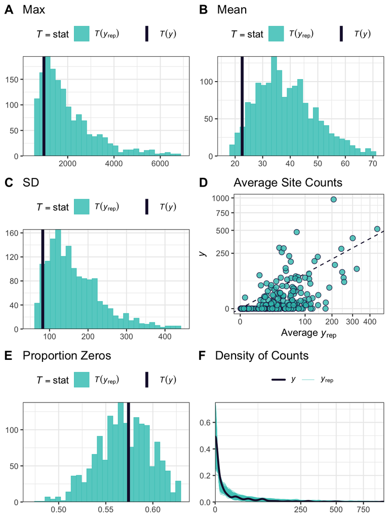

Figure 1: Posterior predictive checks for Sambar Deer

```r
q95 <- function(x) quantile(x, 0.95, na.rm = T)
# q25 <- function(x) quantile(x, 0.25, na.rm = T)
q75 <- function(x) quantile(x, 0.75, na.rm = T)
sd_90 <- function (x, na.rm = FALSE) {
  quants <- quantile(x, c(0.05, 0.95), na.rm = T)
  x <- x[x < quants[2] & x > quants[1]]
  sqrt(var(if (is.vector(x) || is.factor(x)) x else as.double(x),
    na.rm = na.rm))
}

bayes_theme <- c(delwp_cols_seq$Teal[6:8], delwp_cols_shades$Navy[1:3])

bayesplot::color_scheme_set(bayes_theme)

funs <- c(max, mean, sd, ppc_scatter_avg, prop_zero, ppc_dens_overlay)
titles <- c("Max", "Mean", "SD", "Average Site Counts", "Proportion Zeros", "Density of Counts")

ppc_sambar <- list()

# funs <- c(prop_zero, mean, q90, sd)

for(i in 1:length(funs)) {
ppc_sambar[[i]] <- posterior_checks_multispecies(model = model_fits[[top]],
                 model_data = multispecies_data, species_index = 1,
                 stat = funs[[i]], integrated = T, only_det = F,
                 title = titles[i])
}

cowplot::plot_grid(plotlist = ppc_sambar, labels = "AUTO", ncol = 2)
```

### Fallow Deer

The PPC’s below show that fallow has more dispersion in camera counts than Sambar. While the observed counts fall within the intervals of our model, there is higher uncertainty. Some of these findings appear to be driven by a site with very high counts (over 2,000 snapshot moments of deer individuals), this is more than twice the second highest.

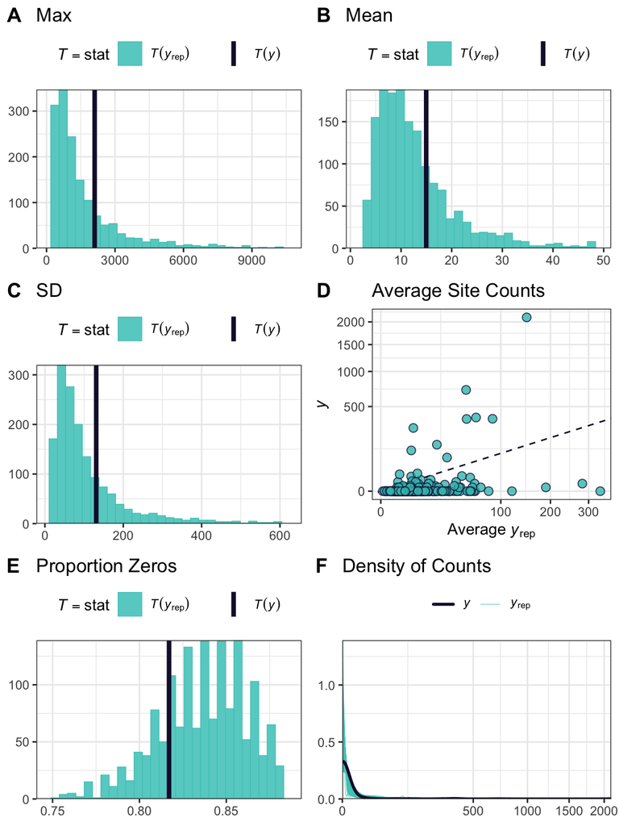

Figure 2: Posterior predictive checks for Fallow Deer

```r
ppc_fallow <- list()

for(i in 1:length(funs)) {
ppc_fallow[[i]] <- posterior_checks_multispecies(model = model_fits[[top]],
                 model_data = multispecies_data, species_index = 2,
                 stat = funs[[i]], integrated = T, only_det = F,
                 title = titles[i])
}

cowplot::plot_grid(plotlist = ppc_fallow, labels = "AUTO", ncol = 2)
```

### Red Deer

Red Deer have PPC’s that show a high congruence between predicted and expected counts.

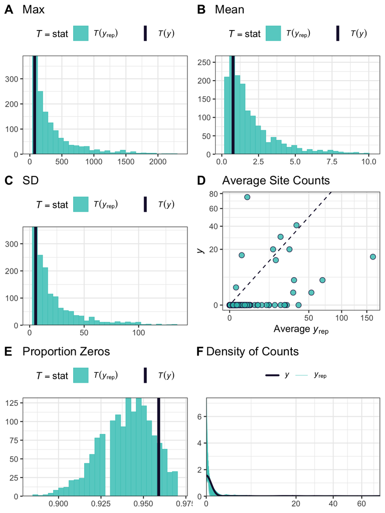

Figure 3: Posterior predictive checks for Red Deer

```r
ppc_red <- list()

for(i in 1:length(funs)) {
ppc_red[[i]] <- posterior_checks_multispecies(model = model_fits[[top]],
                 model_data = multispecies_data, species_index = 3,
                 stat = funs[[i]], integrated = T,
                 title = titles[i])
}

cowplot::plot_grid(plotlist = ppc_red, labels = "AUTO", ncol = 2)
```

### Hog Deer

Hog Deer have PPC’s that show our model performs sufficiently well in explaining the patterns of observed counts.

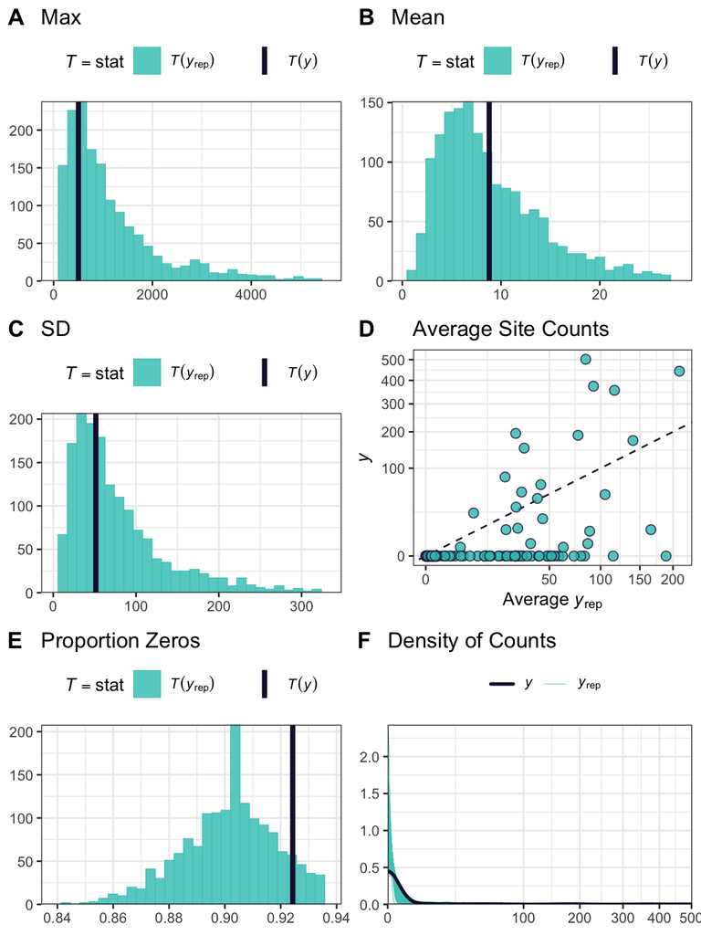

Figure 4: Posterior predictive checks for Hog Deer

```r
ppc_hog <- list()

for(i in 1:length(funs)) {
ppc_hog[[i]] <- posterior_checks_multispecies(model = model_fits[[top]],
                 model_data = multispecies_data, species_index = 4,
                 stat = funs[[i]], integrated = T,
                 title = titles[i])
}

cowplot::plot_grid(plotlist = ppc_hog, labels = "AUTO", ncol = 2)
```

## Model Convergence

We observed no divergences or any STAN sampling warnings/issues for our models. To visualise the convergence of the model we can observe the mixing of chains for key parameters below:

- `beta_det`: Parameters for the distance sampling model (intercept and herbaceous understorey)
- `beta_psi`: Parameters for the fixed effect abundance model
- `bioregion_sd`: Parameter for the bioregion random effect standard deviation
- `odRN`: Parameter for the over-dispersion in the Royle-Nichols negative binomial model
- `od_mu`: Parameters for the mean over-dispersion for each species for the camera counts (combined with odRN).

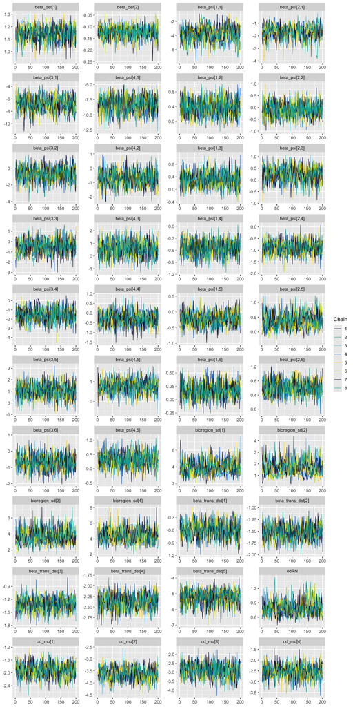

Figure 5: Chain mixing of several key parameters relating to detection, abundance and dispersion

```r
bayesplot::color_scheme_set(unname(delwp_cols[1:6]))
convergence_params <- model_fits[[top]]$draws(c("beta_det",
                                                "beta_psi",
                                                "bioregion_sd",
                                                "beta_trans_det",
                                                "odRN",
                                                "od_mu"))

mcmc_trace(convergence_params, facet_args = list(ncol = 4)) +
  theme(panel.spacing = unit(0.5, "lines"))
```

# Model Predictions

Within the STAN model we generate predictions for sampled and un-sampled locations. This provides us with site-level abundance estimates as well as estimates across all (un-sampled) public forest.

## Site-based Predictions

### Site-based Detections Map

Below we display a detection/non-detection map for all sites. Detections are recorded from either camera or transect detections.

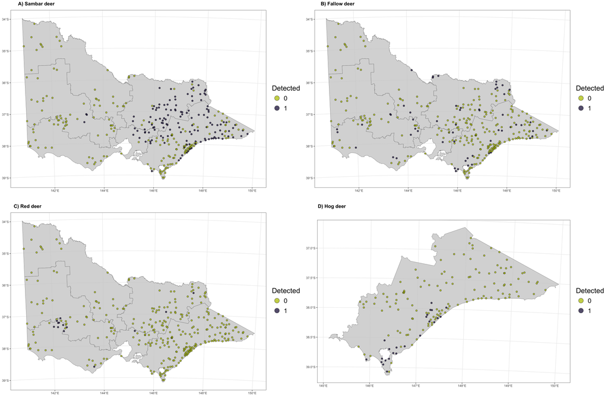

Figure 6: Detections of deer (camera or transects) from across Victoria. Detections of Hog Deer are restricted to Gippsland.

```r
vic_regions <- vicmap_query("open-data-platform:delwp_region") %>%
  collect() %>%
  st_transform(3111) %>%
  st_simplify(dTolerance = 500)

delwp_pal <- colorRampPalette(c("#B9C600",
                                delwp_cols[["Teal"]],
                                delwp_cols[["Navy"]]))

site_detection_plot <- function(data, regions, cams_curated, species_index) {

  cam_data <- cams_curated %>% dplyr::select(SiteID)

  cam_data$Detected <- factor(data$any_seen[species_index, ])
  cam_data$cam_seen <- factor(as.integer(as.logical(rowSums(data$n_obs[,,species_index]))))

  if(species_index == 4) {
    regions <- regions %>% filter(delwp_region == "GIPPSLAND")
    cam_data <- cam_data %>% st_filter(regions %>% st_transform(4283))
  }

   lvls <- length(unique(cam_data$Detected, na.rm = T))

plot <- ggplot2::ggplot(data = cam_data %>% st_transform(3111)) +
  ggplot2::geom_sf(data = regions, alpha = 0.75, fill = "grey80") +
  ggplot2::geom_sf(aes(fill = Detected), shape = 21, size = 2, alpha = 0.75) +
  ggplot2::scale_fill_manual(values = delwp_pal(lvls),
                             na.value = "transparent", na.translate = F,
                             name = "Detected", guide = guide_legend(override.aes = list(size = 6))) +
  # ggtitle(species_names[species_index])+
  theme_bw() +
  theme(legend.text = element_text(size = 18), legend.key.size = unit(1, "cm"),
        title = element_text(size = 20))

return(plot)

}

detection_plot <- cowplot::plot_grid(site_detection_plot(multispecies_data, regions = vic_regions, cams_curated = cams_curated, species_index = 1),
site_detection_plot(multispecies_data, regions = vic_regions, cams_curated = cams_curated, species_index = 2),
site_detection_plot(multispecies_data, regions = vic_regions, cams_curated = cams_curated, species_index = 3),
site_detection_plot(multispecies_data, regions = vic_regions, cams_curated = cams_curated, species_index = 4), ncol = 2,
labels = c("A) Sambar deer", "B) Fallow deer", "C) Red deer", "D) Hog deer"), greedy = TRUE)

ggsave(plot = detection_plot, filename = "outputs/plots/all_detection_plot.png", width = 4800, height = 3200, units = "px", bg = "white")

detection_plot
```

### Site-based Prediction Map

Our model generates predictions of density (per km<sup>2</sup>) at each site using the $\lambda$ value at that site, average group size at that site, and the dispersion at that site (varies across species). For this quantity (`N_site`), we plot visualisations of mean estimates for the various deer species surveyed for in this study. We save the numerical values, as a spatial object (`sf`) at `outputs/site_deer_predictions.rds`.

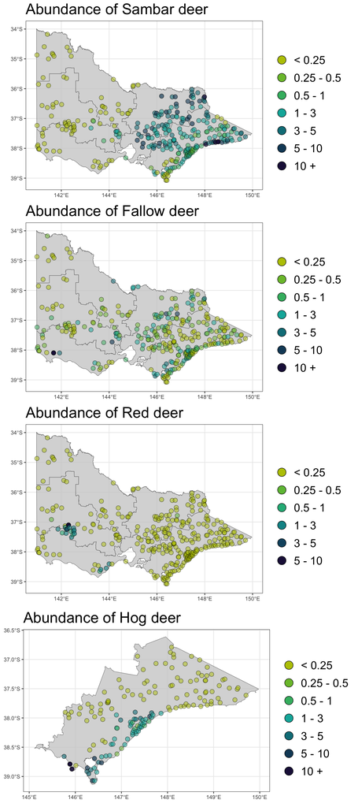

```r
site_preds <- function(model, cams_curated, species_index) {

rn_dens <- model$summary("N_site", prob_occ = ~ mean(. > 0), trimmed_mean = ~mean(., trim = 0.025), CV = ~sd(.)/mean(.), posterior::default_summary_measures(), posterior::default_convergence_measures())

which_sp <- which(stringr::str_detect(string = rn_dens$variable,
                                         pattern = paste0("N_site\\[",
                                                          species_index)))


  density_at_sites_rn <- cbind(cams_curated, rn_dens[which_sp, ])

  return(density_at_sites_rn)
}

site_density_plot <- function(densities, regions, species) {
  densities$density <- cut(densities$mean,
                                   breaks = c(0, 0.25, 0.5, 1, 3, 5, 10, max(densities$mean)),
                                   labels = c("< 0.25",
                                                    "0.25 - 0.5",
                                                    "0.5 - 1",
                                                    "1 - 3",
                                                    "3 - 5",
                                                    "5 - 10",
                                                    "10 +"), include.lowest = T, right = T)

  if(species == "Hog") {
    regions <- regions %>% filter(delwp_region == "GIPPSLAND")
    densities <- densities %>% st_filter(regions %>% st_transform(4283))
  }

   lvls <- length(unique(densities$density, na.rm = T))

plot <- ggplot2::ggplot(data = densities) +
  ggplot2::geom_sf(data = regions, alpha = 0.75, fill = "grey80") +
  ggplot2::geom_sf(aes(fill = density, alpha = mean), shape = 21, size = 3) +
  ggplot2::scale_fill_manual(values = delwp_pal(lvls),
                             na.value = "transparent", na.translate = F,
                             name = "", guide = guide_legend(override.aes = list(size = 6))) +
  scale_alpha_continuous(range = c(0.5,1), guide = "none") +
  labs(title = paste0('Abundance of ',species ,' deer'), fill = bquote('Deer per'~km^2)) +
  theme_bw() +
  theme(legend.text = element_text(size = 18), legend.key.size = unit(1, "cm"),
        title = element_text(size = 20))

return(plot)

}

sambar_preds <- site_preds(model_fits[[top]], cams_curated = cams_curated, species_index = 1)
fallow_preds <- site_preds(model_fits[[top]], cams_curated = cams_curated, species_index = 2)
red_preds <- site_preds(model_fits[[top]], cams_curated = cams_curated, species_index = 3)
hog_preds <- site_preds(model_fits[[top]], cams_curated = cams_curated, species_index = 4)

site_deer_predictions <- list(Sambar = sambar_preds,
                         Fallow = fallow_preds,
                         Red = red_preds,
                         Hog = hog_preds)

saveRDS(site_deer_predictions, "outputs/site_deer_predictions.rds")

cowplot::plot_grid(site_density_plot(sambar_preds, vic_regions, species = "Sambar"),
site_density_plot(fallow_preds, vic_regions, species = "Fallow"),
site_density_plot(red_preds, vic_regions, species = "Red"),
site_density_plot(hog_preds, vic_regions, species = "Hog"), ncol = 1)
```

Average density estimates varied across sites for all four species. Sambar deer were the most commonly detected species on the camera traps (104/317 sites), and density estimates at sites ranged from 0 to 26.68 deer/km<sup>2</sup> (mean = 1.93, sd = 2.72), for fallow, fewer site detections (30), but more variability in site density gave a range between 0 and 35.06 deer/km<sup>2</sup> (mean = 0.72, sd = 2.16). Red deer were only detected on 12 sites with densities ranging from 0 to 6.42 (mean = 0.12, sd = 0.51). Finally, Hog Deer, which were only detected on 22 cameras in South Gippsland, had site densities ranging from 0 to 17.43 deer/km<sup>2</sup> (mean = 0.51, sd = 1.64).

### Site-density Summaries

As a check on model expectations we compare the average modelled densities at sites with (i) no evidence of deer, (ii) evidence of deer present on only transects, (iii) evidence of deer present on only the cameras, and (iv) evidence of deer on both cameras and transect. We expect that average densities are generally higher at sites that detected some form of deer than sites that did not detect any sign of deer. Additionally, we would also expect average densities to be generally higher at sites that had detections on cameras than those with only detections from transects. The table below shows these expectations to be correct.

```r
density_summary_table <- function(preds, model_data, species, species_index, return_samples = FALSE) {

  cam_seen <- as.integer(as.logical(rowSums(model_data$n_obs[,,species_index])))

  transect_seen <- model_data$transects %>%
    filter(Species == !!deer_species_all[species_index]) %>%
    mutate(NoCam = case_when(Survey == "Camera" ~ 0L,
                             TRUE ~ 1)) %>%
    group_by(SiteID) %>%
    summarise(TransectDet = max(NoCam*Presence)) %>%
    pull(TransectDet)

  preds_sum <- preds %>%
    st_drop_geometry() %>%
    mutate(`Species` = species,
           `CameraDetection` = cam_seen,
           `AnyDetection` = model_data$any_seen[species_index, ],
           `OnlyTransect`  = transect_seen,
           `Detection` = case_when(CameraDetection == 0 & AnyDetection == 0 ~ "Not seen",
                                   CameraDetection == 0 & AnyDetection == 1 ~ "Only detected on transects",
                                   CameraDetection == 1 & OnlyTransect == 0 ~ "Only seen on cameras",
                                   CameraDetection == 1 & OnlyTransect == 1 ~ "Seen on both camera and transect"))

  if(return_samples) {
    return(preds_sum)
  }

 preds_sum <- preds_sum %>%
    group_by(`Species`, `Detection`) %>%
    summarise(`Number of Sites` = n(),
              `Average Density` = round(mean(mean), 2),
              `SD between sites` = round(sd(mean), 2)) %>%
    ungroup()

  return(preds_sum)
}

density_summary_long <- bind_rows(
  density_summary_table(sambar_preds, multispecies_data,
                        species = "Sambar", species_index = 1, return_samples = T),
  density_summary_table(fallow_preds, multispecies_data,
                        species = "Fallow", species_index = 2, return_samples = T),
  density_summary_table(red_preds, multispecies_data,
                        species = "Red", species_index = 3, return_samples = T),
  density_summary_table(hog_preds, multispecies_data,
                        species = "Hog", species_index = 4, return_samples = T)) %>%
  mutate(Species = factor(Species, levels = c("Sambar", "Fallow", "Red", "Hog")))

# Get plot of distributions
density_summary <- bind_rows(
  density_summary_table(sambar_preds, multispecies_data,
                        species = "Sambar", species_index = 1),
  density_summary_table(fallow_preds, multispecies_data,
                        species = "Fallow", species_index = 2),
  density_summary_table(red_preds, multispecies_data,
                        species = "Red", species_index = 3),
  density_summary_table(hog_preds, multispecies_data,
                        species = "Hog", species_index = 4)) %>%
  mutate(Species = factor(Species, levels = c("Sambar", "Fallow", "Red", "Hog")))


readr::write_csv(x = density_summary, file = "outputs/tables/site_group_estimates.csv")

ggplot_site_summary <- list()

for(x in c("Sambar", "Fallow", "Red", "Hog")) {

ggplot_site_summary[[x]] <- ggplot(data = density_summary_long %>% filter(Species == x)) +
  ggridges::geom_density_ridges2(aes(x = mean,
                                     y = Detection,
                                     fill = Detection,
                                     colour = Detection),
                                 alpha = 0.5,
                                 scale = 1,
                                 quantile_lines = TRUE, quantiles = 2) +
  geom_label(aes(x = `Average Density`, y = Detection,
                 label = paste0("mean = ",`Average Density`, ", n = ", `Number of Sites`), nudge_y = -0.2),
             data = density_summary %>% filter(Species == x)) +
  scale_fill_manual(values = delwp_pal(4)) +
  scale_colour_manual(values = delwp_pal(4)) +
  xlab("Average density at sites") +
  scale_x_sqrt() +
  ggtitle(paste(x, "deer")) +
  # facet_wrap(~Species, scales = "free_x", ncol = 2) +
  delwp_theme() +
  theme(legend.position="none")

ggsave(filename = paste0("outputs/plots/site_densities_", x, ".png"),
       plot = ggplot_site_summary[[x]], width = 2400, height = 1600, units = "px")

}


density_summary %>%
  kbl(format = "html", digits = 2, caption = "Average (mean) density estimates at the various groups of sites (according to detections)") %>%
  kable_styling("striped") %>%
  collapse_rows(1)
```

Table 3: Average (mean) density estimates at the various groups of sites (according to detections)

| Species | Detection | Number of Sites | Average Density | SD between sites |
| --- | --- | --- | --- | --- |
| Sambar | Not seen | 182 | 0.83 | 1.31 |
|  | Only detected on transects | 31 | 2.40 | 1.66 |
|  | Only seen on cameras | 50 | 3.23 | 4.51 |
|  | Seen on both camera and transect | 54 | 4.15 | 2.65 |
| Fallow | Not seen | 259 | 0.59 | 2.25 |
|  | Only detected on transects | 28 | 1.01 | 1.64 |
|  | Only seen on cameras | 20 | 1.36 | 1.36 |
|  | Seen on both camera and transect | 10 | 2.00 | 1.73 |
| Red | Not seen | 304 | 0.05 | 0.21 |
|  | Only detected on transects | 1 | 1.24 | NA |
|  | Only seen on cameras | 5 | 1.38 | 1.36 |
|  | Seen on both camera and transect | 7 | 1.84 | 2.20 |
| Hog | Not seen | 293 | 0.27 | 1.20 |
|  | Only detected on transects | 2 | 1.71 | 2.24 |
|  | Only seen on cameras | 22 | 3.55 | 3.09 |

## Regional and Statewide Abundance

Within our model we calculate abundance/density for deer in each of the 74,570 km<sup>2</sup> of public land. Based on these spatial predictions we can estimate abundance at a regional level (6 DEECA regions) and across the whole state.

### Statewide Maps

Using the model predictions (`pred`) for all suitable public land we generate a raster (1km<sup>2</sup> resolution). We save the average spatial estimates under `outputs/rasters` (`.tif` files) and also provide binned plots (png files) in `outputs/plots`.

```r
pred_raster_full <- terra::rast(prediction_raster)

pred_raster <- terra::app(pred_raster_full[[stringr::str_subset(
  stringr::str_remove_all(labels(terms(ab_formula_1)),
                          "scale[(]|[)]|log[(]|sqrt[(]"),
  pattern = "[*]", negate = T)]], mean)

mean_raster <- list()
sd_raster <- list()
mean_raster_discrete <- list()

# gp_preds_draws_all <- model_fits[[top]]$draws("pred", format = "matrix")
gp_preds_draws_all <- model_fits[[top]]$draws("pred", format = "matrix")
# gp_preds_summary_all <- model_fits[[top]]$summary("pred", prob_occ = ~ mean(. > 0))


for(i in 1:length(deer_species_all)) {

which_sp <- which(stringr::str_detect(string = colnames(gp_preds_draws_all),
                                         pattern = paste0("pred\\[", i)))

gp_preds_draws_sp <- gp_preds_draws_all[,which_sp]

terra::values(pred_raster)[!is.na(terra::values(pred_raster))] <- apply(gp_preds_draws_sp,
                                                                        2,
                                                                        mean,
                                                                        na.rm = T) #filter out highest draw

mean_raster[[i]] <- pred_raster
mean_raster_discrete[[i]] <- mean_raster[[i]]
max_pred <- max(values(mean_raster[[i]]), na.rm = T)

values(mean_raster_discrete[[i]]) <- cut(values(mean_raster_discrete[[i]]) ,
                                         breaks = c(0,0.25,0.5,1,3,5,10,max_pred),
                                         include.lowest = T, right = T,
                                         labels = c("< 0.25",
                                                    "0.25 - 0.5",
                                                    "0.5 - 1",
                                                    "1 - 3",
                                                    "3 - 5",
                                                    "5 - 10",
                                                    "10 +"))

# occ_raster[[i]] <- pred_raster
# terra::values(occ_raster[[i]])[!is.na(terra::values(occ_raster[[i]]))] <- apply(gp_preds_draws_sp, 2, function(x) sum(x > 0)/length(x))

sd_raster[[i]] <- pred_raster
terra::values(sd_raster[[i]])[!is.na(terra::values(sd_raster[[i]]))] <- apply(gp_preds_draws_sp, 2, sd)

}

# combine mean rasters together
combined_raster <- rast(mean_raster)
names(combined_raster) <- c("Average Sambar Deer Density (per km2)",
                            "Average Fallow Deer Density (per km2)",
                            "Average Red Deer Density (per km2)",
                            "Average Hog Deer Density (per km2)")

combined_sd_raster <- rast(sd_raster)
names(combined_sd_raster) <- c("Sambar Deer SD",
                            "Fallow Deer SD",
                            "Red Deer SD",
                            "Hog Deer SD")

# combined_occupancy_raster <- rast(occ_raster)
# names(combined_occupancy_raster) <- c("Average Sambar Deer Occupancy Probability",
#                             "Average Fallow Deer Occupancy Probability",
#                             "Average Red Deer Occupancy Probability",
#                             "Average Hog Deer Occupancy Probability")

# writeRaster(combined_occupancy_raster, "outputs/rasters/combined_occupancy_raster.tif", overwrite = T)
writeRaster(combined_raster, "outputs/rasters/combined_deer_average_density.tif", overwrite = T)
writeRaster(combined_sd_raster, "outputs/rasters/combined_deer_sd.tif", overwrite = T)
```

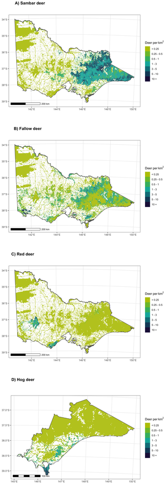

```r
# reg <- vicspatial::vicmap_query("open-data-platform:delwp_region") %>%
#     vicspatial::collect() %>%
#   sf::st_transform(3111) %>%
#   sf::st_simplify(dTolerance = 250)
state <- vicspatial::vicmap_query("open-data-platform:vmlite_victoria_polygon_su5") %>%
  filter(state != "NSW" & state != "SA" & feature_type_code != "sea") %>%
  vicspatial::collect() %>%
  sf::st_transform(3111)

gippsland <- vic_regions %>% filter(delwp_region == "GIPPSLAND")

plot_abundance <- function(raster, state, species, crop = NULL) {

  if(!is.null(crop)) {
    raster <- terra::crop(raster, vect(crop), mask = T)
    state <- crop
  }

  lvls <- length(unique(values(raster, na.rm = T)))

  plot <- ggplot2::ggplot() +
    tidyterra::geom_spatraster(data = raster, na.rm = T) +
    # tidyterra::scale_fill_terrain_d(na.translate = FALSE) +
    ggplot2::scale_fill_manual(values = delwp_pal(lvls), na.value = "transparent", na.translate = F) +
    ggplot2::labs(fill = bquote('Deer per'~km^2)) +
    ggspatial::annotation_scale() +
    ggplot2::geom_sf(data = state, alpha = 0.1, linewidth = 0.5, fill = "grey90") +
    delwp_theme()

  return(plot)

}

sambar_abundance_plot <- plot_abundance(mean_raster_discrete[[1]],
                                        state = state,
                                        species = "Sambar Deer")
fallow_abundance_plot <- plot_abundance(mean_raster_discrete[[2]],
                                        state = state,
                                        species = "Fallow Deer")
red_abundance_plot <- plot_abundance(mean_raster_discrete[[3]],
                                     state = state,
                                     species = "Red Deer")
hog_abundance_plot <- plot_abundance(mean_raster_discrete[[4]],
                                     state = state, crop = gippsland,
                                     species = "Hog Deer")

ggsave(plot = sambar_abundance_plot, filename = "outputs/plots/sambar_abundance_plot.png",
       width = 2400, height = 1600, units = "px")
ggsave(plot = fallow_abundance_plot, filename = "outputs/plots/fallow_abundance_plot.png",
       width = 2400, height = 1600, units = "px")
ggsave(plot = red_abundance_plot, filename = "outputs/plots/red_abundance_plot.png",
       width = 2400, height = 1600, units = "px")
ggsave(plot = hog_abundance_plot, filename = "outputs/plots/hog_abundance_plot.png",
       width = 2400, height = 1600, units = "px")

ggsave(plot = cowplot::plot_grid(sambar_abundance_plot, fallow_abundance_plot, red_abundance_plot, hog_abundance_plot, ncol = 2, labels = c("A) Sambar deer", "B) Fallow deer", "C) Red deer", "D) Hog deer"), greedy = F), filename = "outputs/plots/all_abundance_plot.png", width = 4800, height = 3200, units = "px", bg = "white")

cowplot::plot_grid(sambar_abundance_plot, fallow_abundance_plot, red_abundance_plot, hog_abundance_plot, ncol = 1, labels = c("A) Sambar deer", "B) Fallow deer", "C) Red deer", "D) Hog deer"))
```

### Regional Abundance Estimates

For each DEECA region we provide species-level estimates of abundance with 90 % confidence interval. We also calculate the model-based average density within each region based on the abundance and the total area of public land within each region.

```r
Nhat_sum <- model_fits[[top]]$summary("Nhat", trimmed_mean = ~mean(., trim = 0.025), CV = ~sd(.)/mean(.), posterior::default_summary_measures(), posterior::default_convergence_measures())

Nhat_all <- model_fits[[top]]$summary("Nhat_sum", trimmed_mean = ~mean(., trim = 0.025), CV = ~sd(.)/mean(.), posterior::default_summary_measures(), posterior::default_convergence_measures())

format_nhat <- function(sp, data = Nhat_sum) {
  fd <- data %>%
    filter(variable == !!paste0("Nhat[", sp, "]"))

  paste0("$\\hat N$ = ",
         formatC(fd$trimmed_mean, digits = 0, big.mark = ",", format = "f"),
        " [90% CI: ",
        formatC(fd$q5, digits = 0, big.mark = ",", format = "f"),
        " – ",
        formatC(fd$q95, digits = 0, big.mark = ",", format = "f"),
        "]")
}

reg <- vicspatial::vicmap_query("open-data-platform:delwp_region") %>%
    vicspatial::collect() %>%
    dplyr::group_by(delwp_region) %>%
    dplyr::summarise(geometry = sf::st_combine(geometry)) %>%
    dplyr::ungroup() %>%
    dplyr::mutate(delwp_region_fact = as.integer(factor(delwp_region)))

abundance_table <- function(model, regions, pred_area, caption, species_index, return_data = F) {

  reg <- model$summary("Nhat_reg", prob_occ = ~ mean(. > 0), trimmed_mean = ~mean(., trim = 0.025), posterior::default_summary_measures(), posterior::default_convergence_measures())

  which_sp <- which(stringr::str_detect(string = reg$variable,
                                         pattern = paste0("Nhat_reg\\[", species_index)))

  regional_abundance <- reg[which_sp,] %>%
    dplyr::bind_rows(model$summary("Nhat", prob_occ = ~ mean(. > 0), trimmed_mean = ~mean(., trim = 0.025), posterior::default_summary_measures(), posterior::default_convergence_measures())[species_index,]) %>%
    dplyr::mutate(variable = c(regions$delwp_region, "TOTAL"),
                  `Area km2` = round(c(pred_area, sum(pred_area))),
                  `Density (mean)` = round(trimmed_mean/`Area km2`, 2),
                  `Density (5 %)` = round(q5/`Area km2`, 2),
                  `Density (95 %)` = round(q95/`Area km2`, 2),
                  `Density mean (90% CI)` = paste0(`Density (mean)`,
                                                   " (",
                                                   `Density (5 %)`,
                                                   ", ",
                                                   `Density (95 %)`,
                                                   ")"),
                  CV = round(sd/trimmed_mean, 2)) %>%
    dplyr::transmute(Region = variable,
                  `Trimmed mean` = round(trimmed_mean),
                  # Median = round(median),
                  SD = round(sd),
                  CV,
                  # MAD = round(mad),
                  `5 %` = round(q5),
                  `95 %` = round(q95),
                  `Area km2`,
                  `Density mean (90% CI)`)

  if(return_data) {

 if(species_index == 4) {
    regional_abundance <- regional_abundance %>%
      filter(Region == "GIPPSLAND")
  }

    return(regional_abundance %>%
             mutate(Species = species_names[species_index], across(c(2,3,5:8), ~ formatC(.x, digits = 0, format = "f", big.mark = ",") )) %>%
             dplyr::select(Species, everything()))
  }

  kableExtra::kbl(regional_abundance, digits = 2, format = "html", caption = caption, format.args = list(big.mark = ",")) %>%
    kableExtra::kable_styling("striped") %>%
    kableExtra::column_spec(1, bold = TRUE) %>%
    kableExtra::row_spec(6, hline_after = T) %>%
    kableExtra::row_spec(7, background = "#A5A1B5", color = "black", bold = T, hline_after = T)
}

pred_a_df <- data.frame(pred_reg = multispecies_data$pred_reg,
                        area = multispecies_data$prop_pred) %>%
  group_by(pred_reg) %>%
  summarise(area = sum(area))

# Save Abundance Table
all_ab_tab <- bind_rows(abundance_table(model_fits[[top]], regions = reg, pred_area = pred_a_df$area, species_index = 1, return_data = T),
                        abundance_table(model_fits[[top]], regions = reg, pred_area = pred_a_df$area, species_index = 2, return_data = T),
                        abundance_table(model_fits[[top]], regions = reg, pred_area = pred_a_df$area, species_index = 3, return_data = T),
                        abundance_table(model_fits[[top]], regions = reg, pred_area = pred_a_df$area, species_index = 4, return_data = T))

write.csv(all_ab_tab, "outputs/tables/regional_abundance_estimates.csv")

abundance_table(model_fits[[top]], regions = reg, pred_area = pred_a_df$area, caption = "Regional estimates of Sambar Deer Density", species_index = 1)
```

Table 4: Regional estimates of Sambar Deer Density

| Region | Trimmed mean | SD | CV | 5 % | 95 % | Area km2 | Density mean (90% CI) |
| --- | --- | --- | --- | --- | --- | --- | --- |
| BARWON SOUTH WEST | 165 | 307 | 1.87 | 42 | 509 | 4,745 | 0.03 (0.01, 0.11) |
| GIPPSLAND | 65,740 | 10,666 | 0.16 | 50,016 | 85,745 | 25,211 | 2.61 (1.98, 3.4) |
| GRAMPIANS | 1,972 | 1,256 | 0.64 | 846 | 3,874 | 9,896 | 0.2 (0.09, 0.39) |
| HUME | 72,047 | 15,277 | 0.21 | 51,703 | 99,869 | 16,890 | 4.27 (3.06, 5.91) |
| LODDON MALLEE | 1,396 | 3,009 | 2.15 | 567 | 3,972 | 15,597 | 0.09 (0.04, 0.25) |
| PORT PHILLIP | 6,307 | 1,666 | 0.26 | 4,116 | 9,541 | 2,231 | 2.83 (1.85, 4.28) |
| TOTAL | 148,189 | 23,973 | 0.16 | 114,557 | 191,777 | 74,570 | 1.99 (1.54, 2.57) |

```r
abundance_table(model_fits[[top]], regions = reg, pred_area = pred_a_df$area, caption = "Regional estimates of Fallow Deer Density", species_index = 2)
```

Table 4: Regional estimates of Fallow Deer Density

| Region | Trimmed mean | SD | CV | 5 % | 95 % | Area km2 | Density mean (90% CI) |
| --- | --- | --- | --- | --- | --- | --- | --- |
| BARWON SOUTH WEST | 12,013 | 14,024 | 1.17 | 3,462 | 35,570 | 4,745 | 2.53 (0.73, 7.5) |
| GIPPSLAND | 14,327 | 5,493 | 0.38 | 8,028 | 25,317 | 25,211 | 0.57 (0.32, 1) |
| GRAMPIANS | 4,960 | 7,069 | 1.43 | 2,374 | 10,089 | 9,896 | 0.5 (0.24, 1.02) |
| HUME | 18,261 | 6,319 | 0.35 | 10,340 | 30,136 | 16,890 | 1.08 (0.61, 1.78) |
| LODDON MALLEE | 3,727 | 2,521 | 0.68 | 1,633 | 8,412 | 15,597 | 0.24 (0.1, 0.54) |
| PORT PHILLIP | 1,755 | 801 | 0.46 | 882 | 3,250 | 2,231 | 0.79 (0.4, 1.46) |
| TOTAL | 56,172 | 22,576 | 0.40 | 34,042 | 94,960 | 74,570 | 0.75 (0.46, 1.27) |

```r
abundance_table(model_fits[[top]], regions = reg, pred_area = pred_a_df$area, caption = "Regional estimates of Red Deer Density", species_index = 3)
```

Table 4: Regional estimates of Red Deer Density

| Region | Trimmed mean | SD | CV | 5 % | 95 % | Area km2 | Density mean (90% CI) |
| --- | --- | --- | --- | --- | --- | --- | --- |
| BARWON SOUTH WEST | 5,690 | 9,552 | 1.68 | 1,497 | 18,290 | 4,745 | 1.2 (0.32, 3.85) |
| GIPPSLAND | 184 | 176 | 0.96 | 52 | 503 | 25,211 | 0.01 (0, 0.02) |
| GRAMPIANS | 5,230 | 6,922 | 1.32 | 1,596 | 14,862 | 9,896 | 0.53 (0.16, 1.5) |
| HUME | 1,145 | 820 | 0.72 | 420 | 2,670 | 16,890 | 0.07 (0.02, 0.16) |
| LODDON MALLEE | 90 | 1,634 | 18.10 | 1 | 643 | 15,597 | 0.01 (0, 0.04) |
| PORT PHILLIP | 32 | 47 | 1.44 | 6 | 106 | 2,231 | 0.01 (0, 0.05) |
| TOTAL | 12,810 | 15,284 | 1.19 | 4,556 | 35,130 | 74,570 | 0.17 (0.06, 0.47) |

```r
abundance_table(model_fits[[top]], regions = reg, pred_area = pred_a_df$area, caption = "Regional estimates of Hog Deer Density", species_index = 4)
```

Table 4: Regional estimates of Hog Deer Density

| Region | Trimmed mean | SD | CV | 5 % | 95 % | Area km2 | Density mean (90% CI) |
| --- | --- | --- | --- | --- | --- | --- | --- |
| BARWON SOUTH WEST | 0 | 0 | NaN | 0 | 0 | 4,745 | 0 (0, 0) |
| GIPPSLAND | 4,825 | 2,504 | 0.52 | 2,429 | 9,662 | 25,211 | 0.19 (0.1, 0.38) |
| GRAMPIANS | 0 | 0 | NaN | 0 | 0 | 9,896 | 0 (0, 0) |
| HUME | 0 | 0 | NaN | 0 | 0 | 16,890 | 0 (0, 0) |
| LODDON MALLEE | 0 | 0 | NaN | 0 | 0 | 15,597 | 0 (0, 0) |
| PORT PHILLIP | 0 | 0 | NaN | 0 | 0 | 2,231 | 0 (0, 0) |
| TOTAL | 4,825 | 2,504 | 0.52 | 2,429 | 9,662 | 74,570 | 0.06 (0.03, 0.13) |

Deer were found to be widely distributed across Victoria. Across approximately 74,570 km<sup>2</sup> of public land we estimate total deer abundance of the four species investigated in this study (Sambar, Fallow, Red and Hog) at 224,161 (90 % CI: 173,993 - 294,539. Sambar deer were the most populous species across Victoria ($\hat N$ = 148,189 [90% CI: 114,557 – 191,777]), followed by Fallow at $\hat N$ = 56,172 [90% CI: 34,042 – 94,960], Red ($\hat N$ = 12,810 [90% CI: 4,556 – 35,130]), and Hog ($\hat N$ = 4,825 [90% CI: 2,429 – 9,662]).

### Deer Abundance in High Conservation Areas

Below we show code for extracting average abundance and densities for areas listed under the National Parks Act 1975, and greater than 20km<sup>2</sup>.

```r
parkres <- vicmap_query("parkres") %>%
  collect(quiet = TRUE) %>%
  st_transform(3111) %>%
  st_filter(vic_regions)

parkres_grouped <- parkres %>%
  group_by(name, name_short) %>%
  summarise(area = sum(areasqm)/1e6,
            geometry = st_combine(geometry)) %>%
  filter(area > 20) %>%
  ungroup()

ab_e <- terra::extract(combined_raster,
                terra::vect(parkres_grouped),
                fun = "sum", method = "simple", na.rm = T, touches = TRUE) %>%
  `names<-`(c("ID", species_names))

# get abundance estimates
park_ab <- bind_cols(parkres_grouped, round(ab_e[,2:5],0)) %>%
  na.omit() %>%
  mutate(`All Deer` = `Sambar Deer` + `Fallow Deer` + `Red Deer` + `Hog Deer`)%>%
  mutate(across(contains("Deer"), ~ round(.x/area,2), .names = "Density {.col}")) %>%
  mutate(Sambar = paste0(formatC(`Sambar Deer`, format =  "fg", big.mark = ","), " (", `Density Sambar Deer`, ")"),
         Fallow = paste0(formatC(`Fallow Deer`, format =  "fg", big.mark = ","), " (", `Density Fallow Deer`, ")"),
         Red = paste0(formatC(`Red Deer`, format =  "fg", big.mark = ","), " (", `Density Red Deer`, ")"),
         Hog = paste0(formatC(`Hog Deer`, format =  "fg", big.mark = ","), " (", `Density Hog Deer`, ")"),
         All = paste0(formatC(`All Deer`, format =  "fg", big.mark = ","), " (", `Density All Deer`, ")")) %>%
  arrange(desc(`Density All Deer`))

park_averages <- park_ab %>%
  mutate(name = paste0(name, " (", round(area, 0), "km2)")) %>%
  dplyr::select(Reserve = name,
            Sambar, Fallow, Red, Hog, All) %>%
  st_drop_geometry()

# write.csv(park_averages, "outputs/tables/park_averages.csv", row.names = F)
```

## Statewide Distributions

### Distribution from an abundance threshold

From our abundance estimates we can obtain estimates of the distribution of the deer species across Victoria.

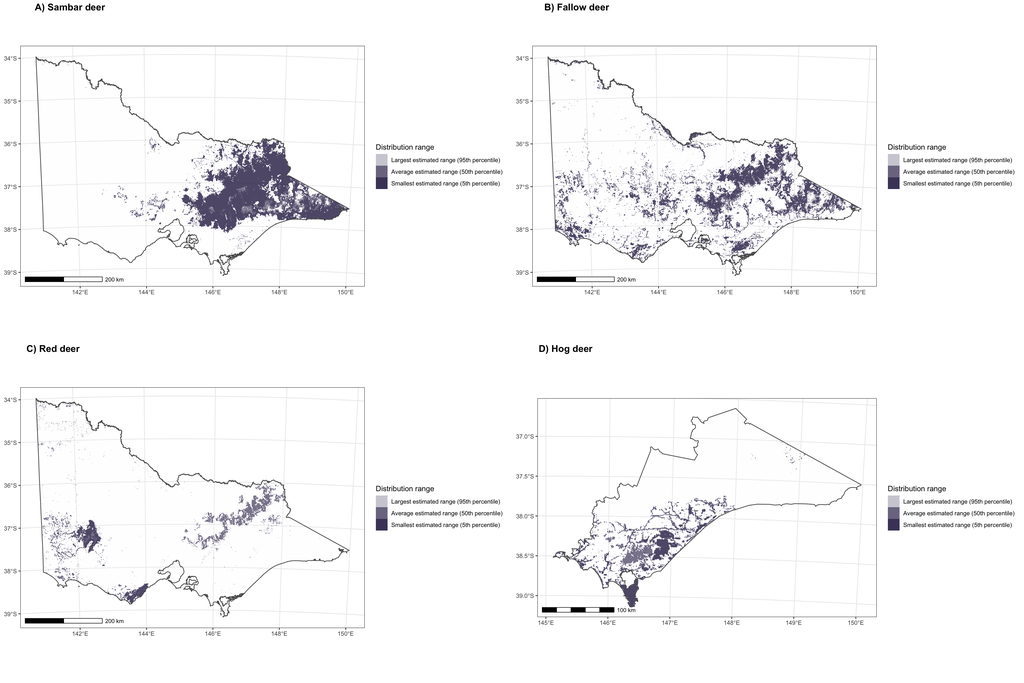

Figure 9: Threshold distributions of Sambar, Fallow, Red and Hog Deer across Victoria, white area reflects area not included in predictions (i.e. not public land), LCI and UCI confidence bounds refer to bootstrapped threshold confidence intervals (90%) for optimal sensitivity and specificity.

```r
inv.cloglog <- function(x) 1-exp(-x)

detections <- function(data, regions, cams_curated, species_index) {

  cam_data <- cams_curated %>% dplyr::select(SiteID)

  cam_data$Detected <- factor(data$any_seen[species_index, ])
  cam_data$cam_seen <- factor(as.integer(as.logical(rowSums(data$n_obs[,,species_index]))))

  # if(species_index == 4) {
  #   regions <- regions %>% filter(delwp_region == "GIPPSLAND")
  #   cam_data <- cam_data %>% st_filter(regions %>% st_transform(4283))
  # }

   return(cam_data)

}

joint_threshold <- list()

combined_threshold <- list()

for(i in 1:length(species_names)) {

dets <- detections(multispecies_data,
                       vic_regions,
                       cams_curated = cams_curated,
                   species_index = i) %>%
  st_make_valid() %>%
  st_transform(3111)

pointVals <- terra::extract(combined_raster[[i]],
               terra::vect(dets %>% st_buffer(1000)), fun = "mean", na.rm = T)[,2]

rocData <- dets[which(!is.na(pointVals)),] %>%
  mutate(lambda = na.omit(pointVals),
         occ = inv.cloglog(lambda))

roc <- roc(rocData$Detected, rocData$lambda)

ci_coords <- ci.coords(roc, "best",
                       best.policy = "random",
                       best.method = "closest.topleft",
                       progress = "none",
                       conf.level = 0.9)

threshold_rast <- combined_raster[[i]]
threshold_rast_lci <- combined_raster[[i]]
threshold_rast_uci <- combined_raster[[i]]

threshold_rast[values(threshold_rast) < ci_coords$threshold[2]] <- 0
threshold_rast[values(threshold_rast) >= ci_coords$threshold[2]] <- 1

threshold_rast_lci[values(threshold_rast_lci) < ci_coords$threshold[3]] <- 0
threshold_rast_lci[values(threshold_rast_lci) >= ci_coords$threshold[3]] <- 1

threshold_rast_uci[values(threshold_rast_uci) < ci_coords$threshold[1]] <- 0
threshold_rast_uci[values(threshold_rast_uci) >= ci_coords$threshold[1]] <- 1

combined_threshold[[i]] <- c(threshold_rast, threshold_rast_lci, threshold_rast_uci) %>% `names<-`(c("Threshold Median", "Threshold LCI", "Threshold UCI"))

joint_threshold[[i]] <- app(combined_threshold[[i]], sum, na.rm = T)

d <- data.frame(id = 0:3, values = c(NA_character_, "Largest estimated range (95th percentile)", "Average estimated range (50th percentile)", "Smallest estimated range (5th percentile)"))

levels(joint_threshold[[i]]) <- d

}

joint_threshold <- rast(joint_threshold)

names(combined_threshold) <- species_names
names(joint_threshold) <- species_names

writeRaster(joint_threshold, "outputs/rasters/combined_threshold_raster.tif", overwrite = TRUE)


get_th_area <- function(stack) {
  med <- sum(values(stack[[1]], na.rm = T) * multispecies_data$prop_pred)
  LCI <- sum(values(stack[[2]], na.rm = T) * multispecies_data$prop_pred)
  UCI <- sum(values(stack[[3]], na.rm = T) * multispecies_data$prop_pred)
  paste0(formatC(med, format = "fg", big.mark = ","), "km^2^ [95% CI: ",
         formatC(LCI, format = "fg", big.mark = ","), ", ",
         formatC(UCI, format = "fg", big.mark = ","), "]")
}

plot_threshold <- function(raster, state, crop = NULL) {

  if(!is.null(crop)) {
    raster <- terra::crop(raster, vect(crop), mask = T)
    state <- crop
  }

  # lvls <- length(unique(values(raster, na.rm = T)))

  plot <- ggplot2::ggplot() +
    tidyterra::geom_spatraster(data = raster, aes(alpha = after_stat(value),
                                                  fill = after_stat(value)), na.rm = T) +
    # tidyterra::scale_fill_terrain_d(na.translate = FALSE) +
    ggplot2::scale_fill_manual(values = unname(rep(delwp_cols[2], 3)),
                               na.value = "transparent",
                               na.translate = F) +
    ggplot2::scale_alpha_manual(values = c(0.25, 0.65, 0.85),
                                na.value = "transparent",
                                na.translate = F) +
    ggplot2::labs(alpha = "Distribution range", fill = "Distribution range") +
    ggspatial::annotation_scale() +
    ggplot2::geom_sf(data = state, alpha = 0.1, linewidth = 0.5, fill = "grey98") +
    delwp_theme()

  return(plot)

}

sambar_th <- plot_threshold(joint_threshold[[1]],
               state = state)

fallow_th <- plot_threshold(joint_threshold[[2]],
               state = state)

red_th <- plot_threshold(joint_threshold[[3]],
               state = state)

hog_th <- plot_threshold(joint_threshold[[4]],
               state = state, crop = gippsland)

threshold_combined_plot <- cowplot::plot_grid(sambar_th, fallow_th, red_th, hog_th, ncol = 2, labels = c("A) Sambar deer", "B) Fallow deer", "C) Red deer", "D) Hog deer"), greedy = F)

ggsave(plot = threshold_combined_plot, filename = "outputs/plots/all_threshold_plot.png", width = 4800, height = 3200, units = "px", bg = "white")

threshold_combined_plot
```

We obtained a threshold distribution based on the mean abundance values for each grid cell. Our range estimates suggest Sambar Deer have a range of 39,113km<sup>2</sup> [95% CI: 34,109, 40,691]. For Fallow deer the range estimate has more variability 27,115km<sup>2</sup> [95% CI: 22,344, 29,606], this is similarly the case for Red Deer (10,175km<sup>2</sup> [95% CI: 2,806, 10,832]). Lastly, Hog Deer have a more isolated range estimate (2,180km<sup>2</sup> [95% CI: 1,467, 2,214]).

### Comparison of range size to existing distributions

Using range size maps based on presence-only records and VBA elicitation (Forsyth, Stamation, and Woodford 2015, 2016) we can generate estimated existing distributions for the deer species on public land:

```r
existing_dist <- list()
existing_dist[["Sambar"]] <- st_read("data/existing_distributions/Sambar_Deer_Distributions_Final_20201203", quiet = TRUE)
existing_dist[["Fallow"]] <- st_read("data/existing_distributions/Fallow_Deer_Distributions_Final_20201203", quiet = TRUE)
existing_dist[["Red"]] <- st_read("data/existing_distributions/Red_Deer_Distributions_Final_20201203", quiet = TRUE)
existing_dist[["Hog"]] <- st_read("data/existing_distributions/Hog_Deer_Distribution_20160329", quiet = TRUE)



crown_land <- readRDS("data/crown_land.rds")

# Get overlapping CA
existing_dist_cl <- lapply(existing_dist, FUN = function(x) {
  d <- st_transform(x, 3111)
  st_intersection(d, crown_land) %>%
    st_union()
})

existing_ranges <- sapply(existing_dist_cl, st_area) %>%
  units::set_units("m2") %>%
  units::set_units("km2") %>%
  formatC(., digits = 0, format = "fg", big.mark = ",") %>%
  as.character()

gormley_dist_rat <- terra::rast("data/Gormley2011/CurrentDist.asc")
gormleySambarOcc2 <- terra::rast("data/Gormley2011/SambarOcc2.asc")
terra::crs(gormleySambarOcc2) <- terra::crs(combined_raster[[1]])
values(gormleySambarOcc2) <- values(gormleySambarOcc2)/100
# terra::crs(vic_preds_terra_th) <- terra::crs(processed_stack)
terra::crs(gormley_dist_rat) <- terra::crs(combined_raster[[1]])
values(gormley_dist_rat)[values(gormley_dist_rat) == 0] <- NA

values(gormleySambarOcc2)[values(gormleySambarOcc2) >= 0.4] <- 1
values(gormleySambarOcc2)[values(gormleySambarOcc2) < 0.4] <- NA
levels(gormleySambarOcc2) <- data.frame(id = 1, values = "2011: Gormley et al (32,644 km^2^)")

gormley_th_proj <- terra::project(gormleySambarOcc2, combined_raster[[1]])
gormley_th_mask <- terra::mask(gormley_th_proj, combined_raster[[1]])

gormley_dist_rat_proj <- terra::project(gormley_dist_rat, combined_raster[[1]])
gormley_th_mask_kde <- terra::mask(gormley_th_mask, gormley_dist_rat_proj)

sambar_sf_2020 <- existing_dist_cl[[1]] %>%
  sf::st_simplify(dTolerance = 250) %>%
  sf::st_as_sf() %>%
  mutate(value = "2020: Forsyth/ARI 2020 (43,779 km^2^)")

joint_threshold_sambar <- joint_threshold[[1]]

levels(joint_threshold_sambar)[[1]] <- data.frame(id = 0:3,
                                                  values = c(NA,
                                                             "2023: Our Study UCI (40,590 km^2^)",
                                                             "2023: Our Study Median (38,582 km^2^)",
                                                             "2023: Our Study LCI (33,405 km^2^)"))

crown_land_small <- crown_land %>% st_simplify(dTolerance = 250)

sambar_change_plot <- ggplot() +
  ggplot2::geom_sf(data = state, alpha = 1, linewidth = 0.5, fill = "grey98") +
  geom_sf(data = crown_land_small, alpha = 1, linewidth = 0, fill = "grey") +
  geom_spatraster(data = gormley_th_mask_kde, na.rm = T) +
  geom_sf(data = sambar_sf_2020, aes(fill = value)) +
  geom_spatraster(data = joint_threshold_sambar, na.rm = T) +
  ggspatial::annotation_scale() +
  ggplot2::scale_fill_manual(values = c(`2011: Gormley et al (32,644 km^2^)` = "#71C5E8",
                                        `2020: Forsyth/ARI 2020 (43,779 km^2^)` = "#E57200",
                                        `2023: Our Study UCI (40,590 km^2^)` = "#A5A1B5",
                                        `2023: Our Study Median (38,582 km^2^)` = "#4C436B",
                                        `2023: Our Study LCI (33,405 km^2^)` = "#201547") ,
                             na.value = "transparent",
                            na.translate = F, name = "Study") +
  delwp_theme() +
  theme(legend.text = ggtext::element_markdown())

ggsave(plot = sambar_change_plot, filename = "outputs/plots/range_comparison_full.png", width = 4000, height = 2200, units = "px", bg = "white")

names(existing_ranges) <- species_names
existing_ranges
```

```
Sambar Deer Fallow Deer    Red Deer    Hog Deer
   "43,779"    "10,259"     "2,630"     "1,147"
```

# Model Covariates

Our model uses covariates to inform three separate sub-models:

- A distance-sampling detection process in front of the camera
- An imperfect detection/observation model based on the transect methods and the camera survey
- An abundance model based on spatially-derived covariates, as well as a bioregion random effect

The following section explores the effect of these covariates and sub-models on detection and abundance.

## Detection Processes

At a site, there are three processes that may lead us to not record deer on a camera when in reality they occupy the site (whereby the site is the home range area surrounding the camera.) Firstly, deer may be available for detection and enter the sampling area in front of the camera. However, due to a function of their distance from the camera we fail to detect this individual. Secondly, they may occupy a site (known from transect signs) but never enter the camera field of view, in this case we estimate the various detection rates from the various methods. The detection rate of the camera in this method is regarded as the spatial availability of deer for camera trap sampling. Thirdly, we take into account temporal availability via activity time.

### Distance-sampling

Below we show the average detection rate for a given group of deer in front of the camera (up to 12.5m). The average group sizes for the four species 1.21, 1.19, 1.08, 1.14.

```r
det_rates <- model_fits[[top]]$summary("p") %>%
  mutate(var = stringr::str_extract(variable, "(?<=\\[).+?(?=\\])")) %>%
  separate(var, into = c("site", "Group Size"), sep = ",")

av_det_rates <- det_rates %>%
  group_by(`Group Size`) %>%
  summarise(mean = mean(mean)) %>%
  ungroup() %>%
  transmute(`Group Size`,
            `Average Site Detection Probability` = mean)


av_det_rates %>%
  bind_rows() %>%
  arrange(`Group Size`) %>%
  kbl("html", digits = 3, caption = "Average detection rates for different group sizes") %>%
  kable_styling("striped") %>%
  collapse_rows(1)
```

Table 5: Average detection rates for different group sizes

| Group Size | Average Site Detection Probability |
| --- | --- |
| 1 | 0.297 |
| 2 | 0.379 |
| 3 | 0.439 |
| 4 | 0.485 |
| 5 | 0.523 |

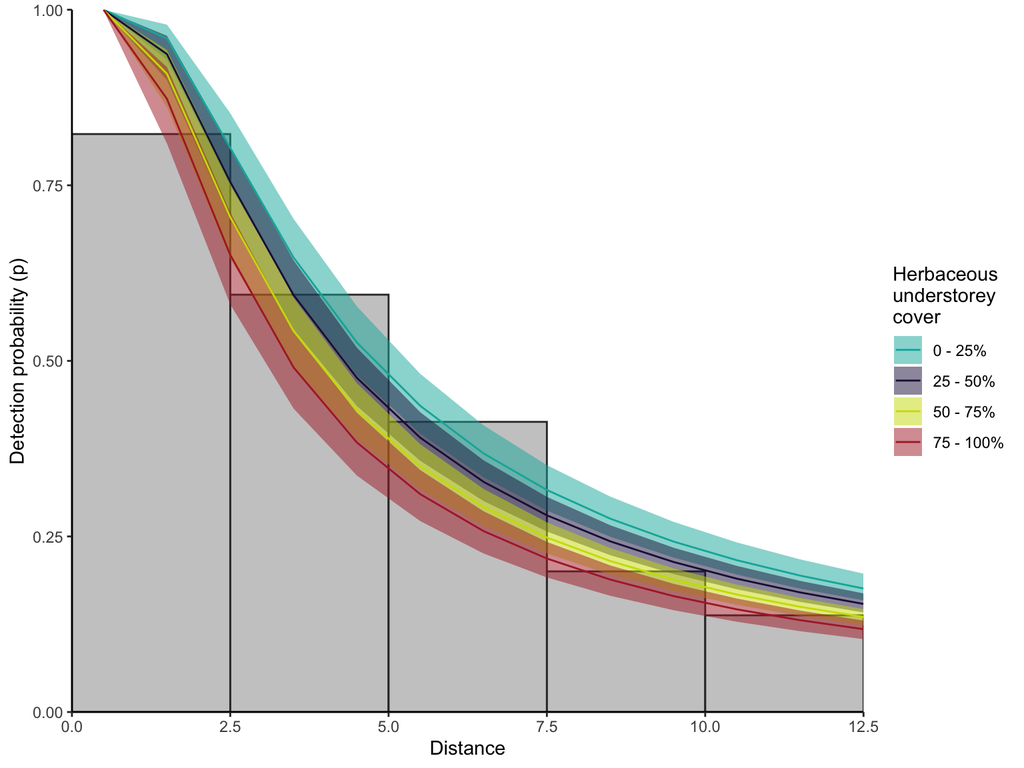

Figure 10: Distance-sampling detection process for Deer (group size = 1-5). Herbaceous understorey cover in the area surrounding appears to have some impact on detection probability

```r
site_vars <- dplyr::tbl(con, dbplyr::in_schema("deervic", "curated_site_data")) %>%
    dplyr::filter(SiteID %in% !!c(cams_curated$SiteID, "47191")) %>%
    dplyr::collect() %>%
    dplyr::mutate(HerbaceousUnderstoryCover = NNWHUCover + ENWHUCover,
           SiteID = dplyr::case_when(SiteID == "47191" & CameraID == "HO04101053" ~ "47191A",
                              SiteID == "47191" & CameraID != "HO04101053" ~ "47191B",
                              TRUE ~ SiteID)) %>% # native + exotic herbaceous cover
    dplyr::arrange(SiteID) %>%
    as.data.frame()

  n_distance_bins <- 5
  delta <- 2.5
  midpts <- c(1.25, 3.75, 6.25, 8.75, 11.25)
  max_distance <- 12.5
  gs <- 1:5

  pa <- matrix(data = NA, nrow = max(gs), ncol = length(midpts))
  for(j in 1:max(gs)) {
    pa[j, ] <- sapply(midpts, function(x) {pr_closest(x-(0.5*delta),
                                                      x+(0.5*delta),
                                                      max_distance = max_distance,
                                                      n = j)})
  }


det_curve <- model_fits[[top]]$draws("DetCurve", format = "draws_matrix") %>%
  as.data.frame() %>%
  # head(250) %>%
  pivot_longer(cols = everything())

det_curve_wr <- det_curve %>%
  mutate(var = stringr::str_extract(name, "(?<=\\[).+?(?=\\])")) %>%
  separate(var, into = c("s", "Distance"), sep = ",") %>%
  mutate(Distance = as.numeric(Distance)-0.5)

det_vars_pred <- site_vars %>%
  mutate(s = as.character(1:nrow(.)),
         herbaceouslvl = cut(HerbaceousUnderstoryCover,
                             breaks = c(0, 25, 50, 75, 105),
                             labels = c("0 - 25%",
                                        "25 - 50%",
                                        "50 - 75%",
                                        "75 - 100%"),
                             include.lowest = T, right = FALSE))

det_curve_sum <- det_curve_wr %>%
  mutate(Distance = as.numeric(Distance)) %>%
  left_join(det_vars_pred) %>%
  group_by(herbaceouslvl, Distance) %>%
  summarise(median = quantile(value, 0.5),
            q5 = quantile(value, 0.05),
            q95 = quantile(value, 0.95))

scaleHN <- det_curve_sum %>% filter(Distance == 1.5) %>% pull(median) %>% mean() # Approx scaling

y_comb_list <- list()
for(i in 1:max(gs)) {
y_comb_list[[i]] <- colSums(multispecies_data$y[,,i]) %>%
  as.data.frame() %>%
  `colnames<-`("Count") %>%
  mutate(Distance = midpts,
         Bin = 1:5,
         gs = i,
         Prop = Count/(max(Count)),
         CountS = Count/pa[Bin,i])

}

y_combined <- bind_rows(y_comb_list) %>%
  group_by(Distance) %>%
  mutate(SumCount = sum(Count)) %>%
  ungroup() %>%
  mutate(propC = Count/SumCount,
         PropSM = (CountS/max(CountS)) * propC)  %>%
  group_by(Distance) %>%
  summarise(PropS = sum(PropSM) * scaleHN)

detection_plot_HN <- ggplot(aes(x = Distance), data = det_curve_sum) +
  geom_col(aes(y = PropS), fill = "grey70", colour = "grey20", width = 2.5, data = y_combined, alpha = 0.7) +
  # geom_error bar(aes(ymin = PropSq5, ymax = PropSq95),  data = y_combined) +
  # geom_line(aes(y = HNS)) +
  geom_ribbon(aes(ymin = q5, ymax = q95, fill = herbaceouslvl), alpha = 0.5) +
  geom_line(aes(y = median, colour = herbaceouslvl)) +
  scale_x_continuous(expand = c(0, 0)) +
  scale_y_continuous(expand = c(0, 0), limits = c(0,1)) +
  scale_fill_manual(values = unname(delwp_cols[c(1,2,3,8)])) +
  scale_colour_manual(values = unname(delwp_cols[c(1,2,3,8)])) +
  ylab("Detection probability (p)") +
  labs(fill = "Herbaceous\nunderstorey\ncover", colour = "Herbaceous\nunderstorey\ncover") +
  theme_classic()

ggsave(plot = detection_plot_HN, filename = "outputs/plots/hazard_detection_plot.png", width = 2400, height = 1600, units = "px")

detection_plot_HN
```

### Transect-surveys

For Sambar, Fallow and Red Deer we were able to estimate detection rates of the various methods used to detect deer (camera, footprints, pellets, rubbings and wallows).

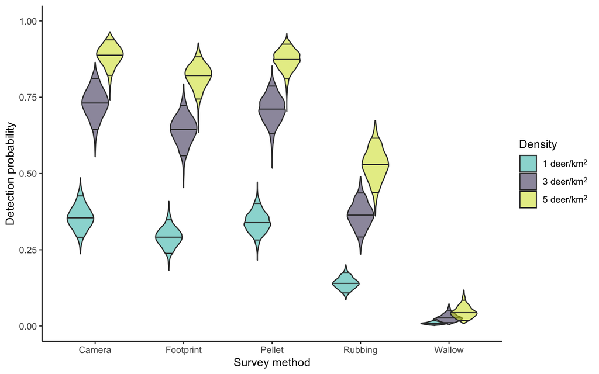

Figure 11: Unconditional detection probabilities for the various methods of survey, across various deer densities. Camera trap detection probability is based on average deployment length (53 days), while transects are based on 3 transect searches

```r
all_draws <- model_fits[[top]]$draws("beta_trans_det", format = "df")

# det_marginal_effects <- list()
# det_plot <- list()

obs_vars <- unlist(stringr::str_remove_all(string = labels(terms(transect_formula)), pattern =  "log|scale|\\)|\\("))
obs_cols <- unlist(stringr::str_remove_all(string = colnames(multispecies_data$trans_pred_matrix), pattern =  "log|scale|\\)|\\("))
obs_logs <- unlist(stringr::str_detect(string = colnames(multispecies_data$trans_pred_matrix), pattern =  "log\\("))

obs_labs <- c("Survey Method")

fac <- c(TRUE, TRUE, TRUE, TRUE, TRUE)
fac2 <- c(TRUE)

det_obs <- multispecies_data$transects %>%
  mutate(Survey = factor(Survey))

det_marginal_effects <- list()
det_plot <- list()

params_w_levs <- levels(det_obs$Survey)

for(i in 1:(length(obs_cols))) {
det_marginal_effects[[i]] <- marginal_effects_cmd(all_draws,
                                              param = "beta_trans_det",
                                              param_number = i, log = obs_logs[i],
                                     model_data = det_obs,
                                     model_column = obs_vars[c(1,attr(multispecies_data$trans_pred_matrix, "assign")[-1])[i]],
                                     transition = FALSE) %>%
  mutate(group = param,
         param = params_w_levs[i],
         factor = fac[i],
         variable = as.numeric(variable))

if(fac[i]) {
  det_marginal_effects[[i]] <- det_marginal_effects[[i]]
}

}

marginal_prob <- function(x, pwr = 3) {
  xm <- 1-x
  return(1-(xm^pwr))
}

det_marginal_effects_bind <- bind_rows(det_marginal_effects) %>%
  rowwise() %>%
  mutate(value = case_when(param != "Camera" ~ marginal_prob(value),
                           TRUE ~ value))

det_marginal_effects_split <- split(det_marginal_effects_bind, det_marginal_effects_bind$group)

for(i in 1:length(det_marginal_effects_split)) {

  if(fac2[i]) {
    plot_data <- det_marginal_effects_split[[i]] %>%
      mutate(variable = param,
             param = group)
  } else {
    plot_data <- det_marginal_effects_split[[i]]
  }

det_plot[[i]] <- plot_data

}
data_for_plot <- bind_rows(det_plot) %>%
  mutate(species = "All (combined)") %>%
  mutate(Density = "1 deer/km^2^")

data_d3 <- data_for_plot %>%
  mutate(value = 1 - (1 - value)^3,
         Density = "3 deer/km^2^")

# d3 averages
data_d3_av <- data_d3 %>%
  group_by(Method = variable) %>%
  summarise(mean = round(mean(value), 2),
            q5 = round(quantile(value, 0.05), 2),
            q95 = round(quantile(value, 0.95), 2)) %>%
  ungroup() %>%
  mutate(label = paste0("*p* = ", mean, " [90% CI: ", q5, ", ", q95, "]")) %>%
  arrange(desc(mean))

data_d5 <- data_for_plot %>%
  mutate(value = 1 - (1 - value)^5,
         Density = "5 deer/km^2^")

data_combined <- bind_rows(data_for_plot, data_d3, data_d5)

transect_det_plot <- marginal_effects_plot_cmd_all(data_combined,
                              factor = TRUE,
                              ylab = "Detection probability") +
  xlab("Survey method") +
  scale_y_continuous(limits = c(0,1)) +
  theme(legend.position = "top") +
  scale_fill_manual(values = unname(delwp_cols[c(1,2,3)])) +
  # scale_x_discrete(expand = c(0, 0)) +
  theme_classic() +
  theme(legend.text = ggtext::element_markdown())

ggsave(plot = transect_det_plot, filename = "outputs/plots/transect_detection_plot.png", width = 2400, height = 1400, units = "px")

transect_det_plot
```

From these plots we can compare the detection rates between methods. For instance, when deer are present at a density of 3 per km<sup>2</sup>, than the highest probability of detection is from a Camera (*p* = 0.73 [90% CI: 0.65, 0.81]), followed by Pellet (*p* = 0.71 [90% CI: 0.63, 0.79]), Footprint (*p* = 0.64 [90% CI: 0.56, 0.72]), Rubbing (*p* = 0.36 [90% CI: 0.29, 0.43]), and lastly Wallow (*p* = 0.03 [90% CI: 0.01, 0.05]).

### Activity

The proportion of time that deer were active and available for detection was 0.52 (90% CI: 0.48, 0.57). This proportion can be visualised in the following plot:

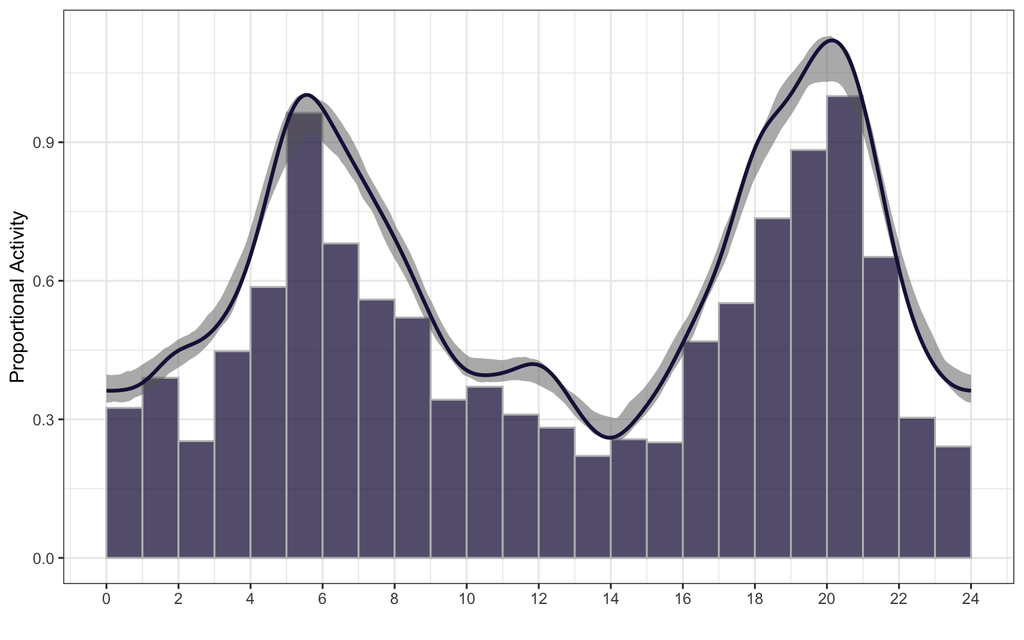

Figure 12: Activity times for all deer shows variable activity time throughout the day

```r
activity_modeled <-model_fits[[top]]$summary("activ")$mean
 #### Availability ####
  #### Determine availability prior ####
  trigger.events <- camtrap_records_deer %>%
    # filter(is.na(Behaviour)) %>% ### Remove biased behaviour
    dplyr::mutate(Sample.Label = as.character(SiteID))

  trigger.events$rtime <- activity::gettime(x = trigger.events$Time,
                                            tryFormats = "%Y-%m-%d %H:%M:%OS")

  act_result <- activity::fitact(trigger.events$rtime,
                                 sample="model",
                                 reps=50,
                                 bw = 30,
                                 show = FALSE)

  avail <- list(creation=data.frame(rate = act_result@act[1],
                                    SE   = act_result@act[2]))

  act_data <- data.frame(x = 12*act_result@data/pi)

  act_model <- as.data.frame(12*act_result@pdf/pi)

  ggplot() +
    geom_histogram(data = act_data, aes(x = x, after_stat(ncount)),
                   breaks = seq(0, 24), width = 2, colour = "grey",
                   fill = delwp_cols[["Navy"]], alpha = 0.75) +
    geom_ribbon(data = act_model, aes(ymin = lcl, ymax = ucl, x = x),
                fill = "grey40", alpha = 0.5) +
    geom_line(data = act_model, aes(y = y, x = x), colour = delwp_cols[["Navy"]], linewidth = 1) +
    # coord_polar(start = 0) +
    scale_fill_brewer() +
    ylab("Proportional Activity") +
    xlab("Time of Day") +
    scale_x_continuous("", limits = c(0, 24),
                       breaks = 2*seq(0, 12),
                       labels = 2*seq(0, 12)) +
    delwp_theme()
```

### Seasonal deployments

Our surveys took place in Spring, Summer and Autumn. Below we show the camera deployment dates for the 317 sites.

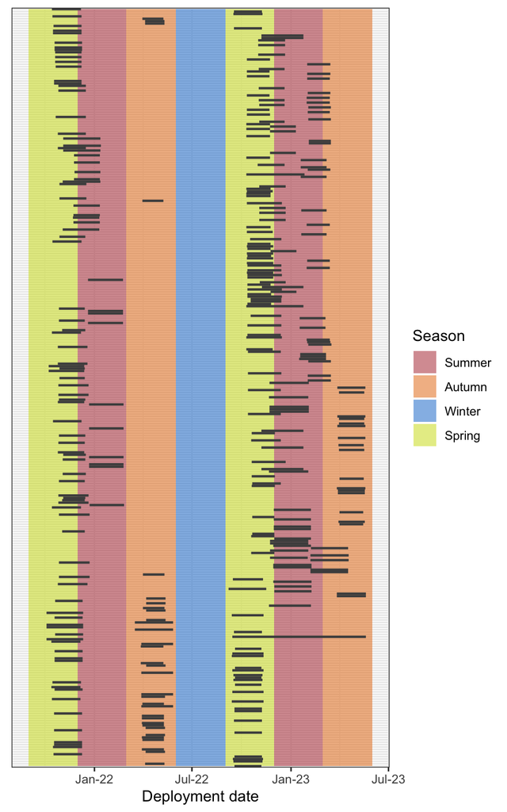

Figure 13: Deployment times of the cameras across the survey period

```r
seasons <- data.frame(Date=seq.Date(from = as.Date("2021-09-01"),
                               to = as.Date("2023-05-01"), by = "month"),
                 Season = c('Spring', 'Spring', 'Spring',
                            'Summer', 'Summer', 'Summer',
                            'Autumn', 'Autumn', 'Autumn',
                            'Winter', 'Winter', 'Winter',
                            'Spring', 'Spring', 'Spring',
                            'Summer', 'Summer', 'Summer',
                            'Autumn', 'Autumn', 'Autumn')) %>%
  mutate(DateEnd = seq.Date(from = as.Date("2021-10-01"),
                               to = as.Date("2023-06-01"), by = "month"),
         Season = factor(Season, levels = c("Summer", "Autumn", "Winter", "Spring"))) %>%
  cross_join(data.frame(SiteID = cams_curated$SiteID)) %>%
  group_by(Date, DateEnd, Season) %>%
  summarise(SiteIDmin = min(SiteID),
            SiteIDmax = max(SiteID)) %>%
  ungroup()


cam_op_plot <- cams_curated %>%
  # mutate(DateDeploy = as.Date(format(DateDeploy, "%m-%d"),"%m-%d"),
  #        DateRetrieve = as.Date(format(DateRetrieve, "%m-%d"), "%m-%d")) %>%
  ggplot() +
    geom_rect(data = seasons, aes(xmin=Date, xmax=DateEnd,
    ymin=SiteIDmin, ymax=SiteIDmax,
    fill=Season
  ), alpha = 0.5) +
  geom_segment(aes(x = DateDeploy, xend = DateRetrieve, y = SiteID, yend = SiteID), linewidth = 0.8, colour = "grey30") +
  scale_x_date(date_breaks = "6 months", date_labels="%b-%y", name = "Deployment date") +
  scale_fill_manual(values = c("#AF272F", "#E57200", "#0072CE", "#CEDC00")) +
  delwp_theme() +
  theme(axis.text.y = element_blank(), axis.ticks.y = element_blank(), axis.title.y = element_blank())

ggsave(plot = cam_op_plot, filename = "outputs/plots/cam_op_plot.png", height = 2400, width = 2000, units = "px")

cam_op_plot
```

## Abundance Processes

### Bioregion

We used a spatially-derived random-effect of the bioregion of the sampled site. This random-effect allows us the ability to make predictions that include the variance associated with this random effect. This random-effect also minimises predictions in areas without deer detection’s (e.g. the mallee).

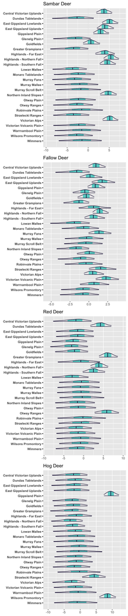

Figure 14: Influence of the bioregion random effect on abundance (log-scale).

```r
bioregion_sd <- model_fits[[top]]$summary("bioregion_sd")

bayesplot::color_scheme_set(bayes_theme)
bioregion_contribution <- function(model, data, species, species_index) {
  eps_bioregion <- model$draws("eps_bioregion", format = "matrix")

  which_sp <- which(stringr::str_detect(string = colnames(eps_bioregion),
                                         pattern = paste0("eps_bioregion\\[", i)))

  eps_bioregion <- eps_bioregion[,which_sp]

  bioregion_data <- data[["bioreg_sf"]]
  colnames(eps_bioregion) <- bioregion_data$bioregion

  plot <- mcmc_areas(eps_bioregion, prob_outer = 0.9) +
    ggtitle(species)

  return(plot)
}

bio_plot_data <- list()

for(i in 1:length(species_names)) {
 bio_plot_data[[i]] <- bioregion_contribution(model = model_fits[[top]],
                         data = multispecies_data,
                         species = species_names[i], species_index = i)
}

cowplot::plot_grid(plotlist = bio_plot_data, ncol = 1)
```

Bioregion usually had a substantial impact on abundance estimates across the state. The variance (standard deviation) associated with the bioregion random effect was large for Sambar ($\sigma$ = 3.98, 90% CI: 2.77 - 5.41), but less for Fallow ($\sigma$ = 1.66, 90% CI: 0.82 - 2.77). Red Deer also exhibited large variance in the bioregion random effect ($\sigma$ = 3.69, 90% CI: 2.44 - 5.19), as well Hog ($\sigma$ = 4.44, 90% CI: 3.17 - 5.9). The larger variances for Hog, Red and Sambar reflect their more refined range boundaries, wheras Fallow show less clear range boundaries and thus show less variance across the state. Below we plot the relative contribution to abundance from each bioregion on a map of Victoria:

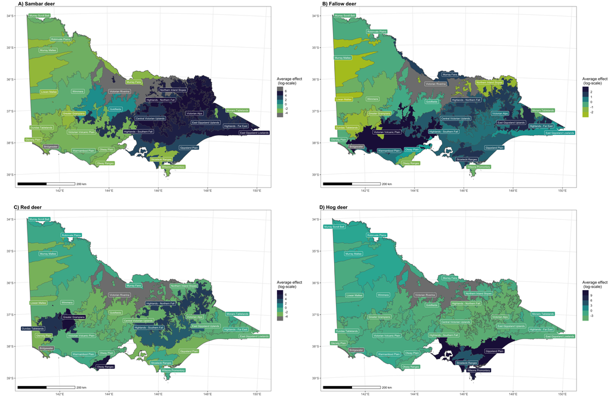

Figure 15: Effect of Victorian Bioregions on abundance of deer

```r
# Bioregion map
bioregion_eff <- model_fits[[top]]$summary("eps_bioregion", posterior::default_summary_measures())

bioreg <- vicspatial::vicmap_query("open-data-platform:vbioreg100") %>%
    vicspatial::collect() %>%
  group_by(bioregion, bioregion_code) %>%
  summarise(geometry = st_union(geometry)) %>%
  ungroup() %>%
  st_transform(3111)

bioregion_nhat <- model_fits[[top]]$summary("Nhat_bioreg", prob_occ = ~ mean(. > 0), trimmed_mean = ~mean(., trim = 0.025), posterior::default_summary_measures())

bioregion_density <- list()

for(i in 1:length(species_names)) {
  which_sp <- which(stringr::str_detect(string = bioregion_nhat$variable,
                                         pattern = paste0("Nhat_bioreg\\[", i)))

  bioregion_nhat_sp <- bioregion_nhat[which_sp,]

  bioregion_nhat_sp$bioregion <- multispecies_data$bioreg_sf$bioregion
  bioregion_nhat_sp$Area <- as.numeric(table(multispecies_data$pred_bioreg))

  bioregion_nhat_sp <- bioregion_nhat_sp %>%
    mutate(`Average Density` = trimmed_mean/Area,
           `Density (5%)` = q5/Area,
           `Density (95%)` = q95/Area,
           `CV` = sd/trimmed_mean,
           label = paste0(bioregion, " [D = "
                          ,round(`Average Density`,2),
                          " (",round(`Density (5%)`,2)," - ",round(`Density (95%)`, 2),")]"))

  bioregion_density[[i]] <- left_join(bioreg, bioregion_nhat_sp, by = "bioregion")

}

bioregion_effects <- list()

for(i in 1:length(species_names)) {
  which_sp <- which(stringr::str_detect(string = bioregion_eff$variable,
                                         pattern = paste0("eps_bioregion\\[", i)))

  bioregion_eff_sp <- bioregion_eff[which_sp,]

  intercept <-  model_fits[[top]]$summary(paste0("beta_psi[",i,",1]"), mean = ~ mean(.))$mean

  bioregion_eff_sp$bioregion <- multispecies_data$bioreg_sf$bioregion
  bioregion_eff_sp$Area <- as.numeric(table(multispecies_data$pred_bioreg))

  bioregion_eff_sp <- bioregion_eff_sp %>%
    mutate(`Average Effect` = mean)

  bioregion_effects[[i]] <- left_join(bioreg, bioregion_eff_sp, by = "bioregion")

}

bioregion_ggplot <- function(effect_df, title) {
  ggplot(data = effect_df) +
    geom_sf(data = state, linewidth = 0.5, fill = "grey90") +
    geom_sf(aes(fill = `Average Effect`)) +
    geom_label_repel(data = effect_df, aes(label = bioregion, fill = `Average Effect`, geometry = geometry),
                  size = 2.5, stat = "sf_coordinates", colour = "white") +
    scale_fill_gradient2(low = "#B9C600",
                         mid = delwp_cols[["Teal"]],
                         high = delwp_cols[["Navy"]], guide = guide_coloursteps(title = "Average effect\n (log-scale)")) +
    labs(x = "", y = "") +
    ggspatial::annotation_scale() +
    delwp_theme()
}

# cl_br <- st_intersection(crown_land, bioreg %>% filter(bioregion == "Bridgewater") %>% st_transform(3111))

cpb <- cowplot::plot_grid(bioregion_ggplot(bioregion_effects[[1]], "Sambar"),
bioregion_ggplot(bioregion_effects[[2]], "Fallow"),
bioregion_ggplot(bioregion_effects[[3]], "Red"),
bioregion_ggplot(bioregion_effects[[4]], "Hog"), labels = c("A) Sambar deer", "B) Fallow deer", "C) Red deer", "D) Hog deer"), ncol = 2)

ggsave(plot = cpb, filename = "outputs/plots/bioregion_effects_plot.png", width = 4800, height = 3200, units = "px", bg = "white")

cpb
```

### Fixed-parameter Effects

Five fixed-effects were included in our multispecies model, with each fixed-effect having a sperately estimated coefficient for each species. Below we shouw the code used to extract and summarise the `beta_psi` coefficients and plot their marginal contribution to abundance.

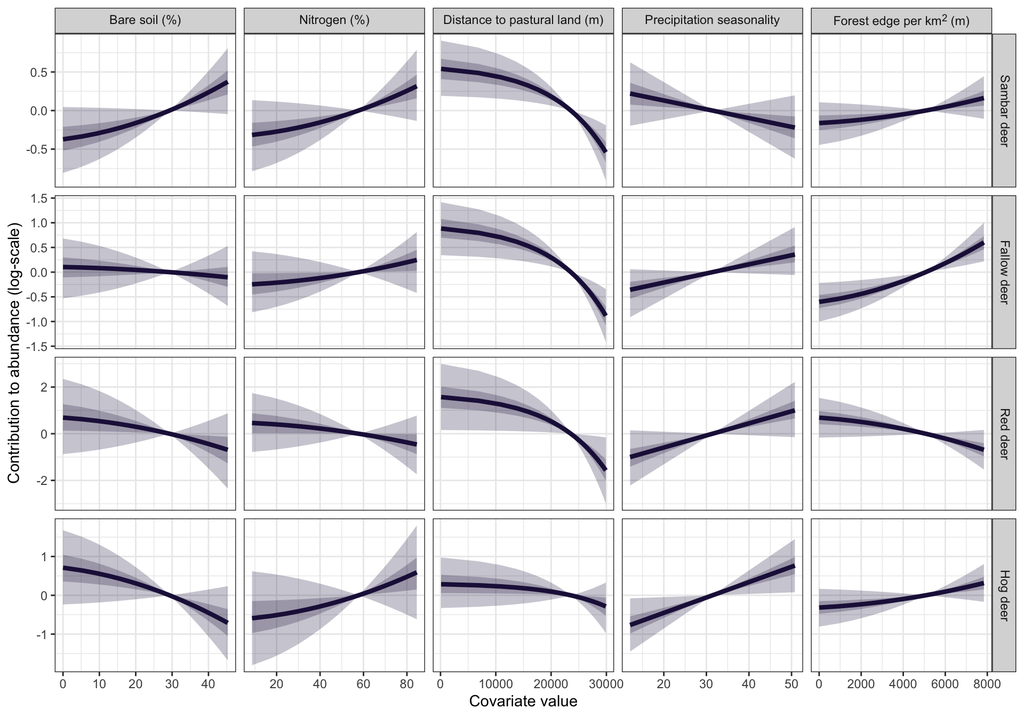

Figure 16: Marginal response curves for the various fixed-effect parameters used in the model.

```r
# beta_summaries
beta_summaries <- model_fits[[top]]$summary("beta_psi")

beta_table_summary <- beta_summaries %>%
  mutate(species = factor(rep(species_names, times = 6),levels = species_names),
         covariate = rep(c("(Intercept)",
              "Bare soil (%)",
              "Nitrogen (%)",
              "Distance to pastural land (m)",
              "Precipitation seasonality",
              'Forest edge per km^2^ (m)'), each = 4)) %>%
  arrange(species) %>%
  select(species, covariate, mean, sd, q5, q95)

format_cov <- function(sp, b, data = beta_summaries, variable = "beta_psi") {
  fd <- data %>%
    filter(variable == !!paste0(variable, "[", sp, ",",b+1,"]"))

  paste0("$\\beta$ = ",
         round(fd$mean, 2),
        " [90% CI: ",
        round(fd$q5, 2),
        " – ",
        round(fd$q95, 2),
        "]")
}

ab_joined_list <- list()
for(j in 1:length(species_names)) {
beta_draws <- model_fits[[top]]$draws("beta_psi", format = "df")

# which_sp <- which(stringr::str_detect(string = colnames(beta_draws),
#                                     pattern = paste0("beta_psi\\[", i)))
#
# beta_draws <- beta_draws[,which_sp]

ab_marginal_effects <- list()
ab_plot <- list()

ab_to_use <- ab_formula_3

phi_vars <- unlist(stringr::str_remove_all(string = labels(terms(ab_to_use)), pattern =  "log|scale|sqrt|\\)|\\("))
phi_logs <- unlist(stringr::str_detect(string = labels(terms(ab_to_use)), pattern =  "log\\("))
phi_sqrts <- c(0.5,0.5,1,1,0.5)

phi_labs <- c("Bare soil (%)",
              "Nitrogen (%)",
              "Distance to pastural land (m)",
              "Precipitation seasonality",
              'Forest edge per km^2^ (m)')

fac <- c(FALSE, FALSE, FALSE, FALSE, FALSE)

for(i in 1:length(phi_vars)) {
ab_marginal_effects[[i]] <- marginal_effects_cmd(beta_draws,
                                              param = "beta_psi", species_index = j,
                                              param_number = i+1, log = phi_logs[i],
                                     model_data = multispecies_data[["raw_data"]] %>% mutate(Nitrogen = Nitrogen*100),
                                     abundance = TRUE,
                                     pwr = phi_sqrts[i],
                                     model_column = phi_vars[i],
                                     transition = FALSE) %>%
  mutate(species = species_names[j])

}
ab_joined_list[[j]] <- bind_rows(ab_marginal_effects)
}

all_me_data <- bind_rows(ab_joined_list) %>%
  mutate(param = case_when(param == "BareSoil" ~ "Bare soil (%)",
                           param == "Nitrogen" ~ "Nitrogen (%)",
                           param == "PastureDistance" ~ "Distance to pastural land (m)",
                           param == "BIO15" ~ "Precipitation seasonality",
                           param == "ForestEdge" ~ 'Forest edge per km^2^ (m)'))


cov_plot <- marginal_effects_plot_cmd_all(all_me_data %>% mutate(species = factor(stringr::str_to_sentence(species), levels = stringr::str_to_sentence(species_names)),
                                                     param = factor(param, levels = phi_labs)),
                          col = "DarkGreen",
                          factor = FALSE,
                          ylab = "Contribution to abundance (log-scale)") +
      ggplot2::facet_grid(species~param, scales = "free") +
  delwp_theme() +
  theme(strip.text = ggtext::element_markdown()) +
  xlab("Covariate value")

ggsave(plot = cov_plot, filename = "outputs/plots/abundance_covariate_effects.png", width = 3000, height = 2000, units = "px")

cov_plot
```

```r
which_sig <- which(beta_table_summary$q5 * beta_table_summary$q95 > 0)

write.csv(beta_table_summary, "outputs/tables/beta_coefs.csv")
beta_table_summary %>%
  kbl("html", digits = 3, caption = "beta-coeffiient estimates for the drivers of species abundance, coefficient estimates not-overalpping zero are shown in bold") %>%
  kable_styling("striped") %>%
  collapse_rows(1) %>%
  row_spec(row = which_sig, bold = TRUE)
```

Table 6: beta-coeffiient estimates for the drivers of species abundance, coefficient estimates not-overalpping zero are shown in bold

| species | covariate | mean | sd | q5 | q95 |
| --- | --- | --- | --- | --- | --- |
| Sambar Deer | (Intercept) | -3.753 | 1.038 | -5.563 | -2.122 |
|  | Bare soil (%) | 0.370 | 0.222 | 0.013 | 0.752 |
|  | Nitrogen (%) | 0.315 | 0.231 | -0.070 | 0.686 |
|  | Distance to pastural land (m) | -0.543 | 0.188 | -0.856 | -0.249 |
|  | Precipitation seasonality | -0.220 | 0.211 | -0.578 | 0.123 |
|  | Forest edge per km<sup>2</sup> (m) | 0.163 | 0.140 | -0.060 | 0.396 |
| Fallow Deer | (Intercept) | -1.685 | 0.510 | -2.577 | -0.910 |
|  | Bare soil (%) | -0.096 | 0.306 | -0.598 | 0.423 |
|  | Nitrogen (%) | 0.230 | 0.316 | -0.314 | 0.724 |
|  | Distance to pastural land (m) | -0.888 | 0.278 | -1.340 | -0.428 |
|  | Precipitation seasonality | 0.375 | 0.249 | -0.002 | 0.798 |
|  | Forest edge per km<sup>2</sup> (m) | 0.600 | 0.197 | 0.274 | 0.931 |
| Red Deer | (Intercept) | -6.785 | 1.132 | -8.670 | -4.954 |
|  | Bare soil (%) | -0.708 | 0.819 | -2.100 | 0.590 |
|  | Nitrogen (%) | -0.460 | 0.647 | -1.535 | 0.590 |
|  | Distance to pastural land (m) | -1.568 | 0.696 | -2.685 | -0.423 |
|  | Precipitation seasonality | 1.031 | 0.597 | 0.086 | 2.064 |
|  | Forest edge per km<sup>2</sup> (m) | -0.690 | 0.433 | -1.388 | 0.009 |
| Hog Deer | (Intercept) | -8.338 | 1.316 | -10.602 | -6.287 |
|  | Bare soil (%) | -0.709 | 0.507 | -1.542 | 0.078 |
|  | Nitrogen (%) | 0.572 | 0.613 | -0.456 | 1.588 |
|  | Distance to pastural land (m) | -0.294 | 0.342 | -0.864 | 0.230 |
|  | Precipitation seasonality | 0.766 | 0.337 | 0.204 | 1.294 |
|  | Forest edge per km<sup>2</sup> (m) | 0.314 | 0.248 | -0.100 | 0.718 |

### Dispersion

Below we show the parameter estimates for the dispersion parameters estimated within our negative binomial models for camera counts and Royle-Nichols model.

```r
dispersion_data <- model_fits[[top]]$summary(c("od", "odRN")) %>%
  mutate(species = c(species_names, "All"),
         model = c(rep("Camera count", 4), "Royle-Nichols"),
         parameter = c("$\\phi_1$", "$\\phi_2$", "$\\phi_3$", "$\\phi_4$", "$\\bar \\phi$")) %>%
  select(model, species, parameter, mean, sd, q5, q95)

format_od <- function(data) {
  paste0(dispersion_data$parameter, " = ", round(dispersion_data$mean, 3), " [90 % CI: ", round(dispersion_data$q5,3), " -- ", round(dispersion_data$q95,3), "]")
}

formatred_od <- format_od(dispersion_data)

dispersion_data %>%
  kbl("html", digits = 3, caption = "Estimates of the dispersion parameter within negative binomial submodels") %>%
  kable_styling("striped") %>%
  collapse_rows(1)
```

Table 7: Estimates of the dispersion parameter within negative binomial submodels

| model | species | parameter | mean | sd | q5 | q95 |
| --- | --- | --- | --- | --- | --- | --- |
| Camera count | Sambar Deer | $\phi_1$ | 0.114 | 0.013 | 0.093 | 0.136 |
|  | Fallow Deer | $\phi_2$ | 0.021 | 0.004 | 0.015 | 0.028 |
|  | Red Deer | $\phi_3$ | 0.046 | 0.016 | 0.024 | 0.075 |
|  | Hog Deer | $\phi_4$ | 0.064 | 0.017 | 0.039 | 0.094 |
| Royle-Nichols | All | $\bar \phi$ | 0.786 | 0.143 | 0.583 | 1.050 |

Estimates of abundance were also dependent upon overdispersion (excess variation) in the camera counts and transect detections. Sambar ($\phi_1$ = 0.114 [90 % CI: 0.093 – 0.136]), Fallow ($\phi_2$ = 0.021 [90 % CI: 0.015 – 0.028]), Red ($\phi_3$ = 0.046 [90 % CI: 0.024 – 0.075]), and Hog Deer ($\phi_4$ = 0.064 [90 % CI: 0.039 – 0.094]) all had large amounts of overdispersion (where lower values (<1) equate to more variance). The Royle-Nichols model had less variance (than camera counts) associated with transect-level detections/non-detections ($\bar \phi$ = 0.786 [90 % CI: 0.583 – 1.05]).

# Relating abundance to vegetation

From our point density estimates of deer, we can model relationships between deer densities at sites and a range of structural vegetation measures collected during the surveys. For this part of the analysis we implement a multivariate regression.

Firstly the response variables we model are:

- Bare Ground Cover (Beta Distribution)
- Native Woody Understorey Cover (Beta Distribution)
- Native Non-woody Understorey Cover (Beta Distribution)
- Presence of seedlings (Negative Binomial Distribution)
- Presence of saplings (Negative Binomial Distribution)
- Presence of exotic flora (Bernoulli Distribution)

While our main predictor of interest is the density of deer at a site, we also control for predictors that are expected to have an impact on vegetation growth and composition. The predictors controlled for include features relating to climate, ecology, topography, fire history and forest structure. They are the following predictors:

- BIO01: Annual Mean Temperature
- BIO04: Temperature Seasonality
- BIO06: Min Temperature of Coldest Month
- BIO12: Annual Precipitation
- BIO15: Precipitation Seasonality (Coefficient of Variation)
- Soil Nitrogen
- Time since last fire (factor grouping)
- TWIND (Topographic wetness index)
- Forest Edge
- Canopy Cover
- Top Height
- Wallaby Presence
- EVC Group (random effect with 19 groups)

## Data Preparation

We can use the sum of estimated deer density for the four species at each site as our key predictor variable. Given that we already extracted a range of bioclimatic and environmental covariates for the original model, we can combine those with the data available here.

Note that this model is run on a subset of sites (sites surveyed as part of the statewide deer survey), as the hog deer sites did not have complete vegetation metrics recorded.

```r
density <- model_fits[[top]]$draws("N_site", format = "matrix")
site_estimates <- list()
site_density <- list()

for(i in 1:n_site) {
  site_estimates[[i]] <- character()
  for(j in 1:length(deer_species_all)) {
    site_estimates[[i]][j] <- paste0("N_site[", j, ",", i, "]")
  }
  site_density[[i]] <- sum(colMeans(density)[site_estimates[[i]]])
}

site_density_ul <- unlist(site_density)

site_density_df <- cams_curated %>%
  mutate(AllDeerDensity = site_density_ul,
         Bioregion = factor(multispecies_data$site_bioreg),
         EVC = factor(multispecies_data$site_evc)) %>%
  filter(ProjectShortName == "StatewideDeer") %>%
  left_join(multispecies_data[["raw_data"]] %>% select(-EVC, - BIOREGION)) %>%
  mutate(TSLF_bin = as.factor(round(TSLF_bin)))

wallaby_pa <- tbl(con, dbplyr::in_schema("camtrap", "processed_site_substation_presence_absence")) %>%
  filter(scientific_name == "Wallabia bicolor" & ProjectShortName %in% project_short_name) %>%
  collect() %>%
  transmute(SiteID,
            Wallaby = as.logical(Presence))

 site_vars <- dplyr::tbl(con, dbplyr::in_schema("deervic", "curated_site_data")) %>%
    dplyr::filter(SiteID %in% !!c(cams_curated$SiteID, "47191")) %>%
    dplyr::collect() %>%
    dplyr::left_join(wallaby_pa) %>%
    dplyr::mutate(HerbaceousUnderstoryCover = NNWHUCover + ENWHUCover,
                  Exotics = EWUCover + ENWHUCover,
                  ExoticPresence = as.integer(as.logical(Exotics)),
                  SeedlingsOrSaplings = as.integer(as.logical(Seedlings+Saplings)),
                  SeedlingsPresence = as.integer(as.logical(Seedlings)),
                  SaplingsPresence = as.integer(as.logical(Saplings)),
                  SiteID = dplyr::case_when(SiteID == "47191" & CameraID == "HO04101053" ~ "47191A",
                                            SiteID == "47191" & CameraID != "HO04101053" ~ "47191B",
                                            TRUE ~ SiteID)) %>% # native + exotic herbaceous cover
    dplyr::arrange(SiteID) %>%
    as.data.frame()

 site_density_df_joined <- site_density_df %>%
   left_join(site_vars) %>%
   mutate(BGroundCover = ifelse(BGroundCover == 0, 0.125, BGroundCover)/100,
             NWUCover = ifelse(NWUCover == 0, 0.125, NWUCover)/100,
             NNWHUCover = ifelse(NNWHUCover == 0, 0.125, NNWHUCover)/100)
```

## Model Execution

We use the `brms` package to run our model in a Bayesian framework (Bürkner 2017, 2018, 2021). Our model is run in parallel on four cores over four chains for 1,000 sampling iterations per chain (1,000 warm up iterations).

```r
bform1 <- bf(mvbind(BGroundCover,
                    NWUCover,
                    NNWHUCover,
                    Seedlings,
                    Saplings,
                    ExoticPresence) ~ AllDeerDensity
                                    + scale(BIO01)
                                    + scale(BIO04)
                                    + scale(BIO06)
                                    + scale(BIO12)
                                    + scale(BIO15)
                                    + scale(Nitrogen)
                                    + TSLF_bin
                                    + scale(TWIND)
                                    + scale(sqrt(ForestEdge))
                                    + scale(sqrt(CanopyCov))
                                    + scale(sqrt(TopHeight))
                                    + Wallaby
                                    + (1|EVC))

# Specifiy model families and links
vegfit <- brm(bform1,
            data = site_density_df_joined,
            family = list(Beta(link = "logit"),
                          Beta(link = "logit"),
                          Beta(link = "logit"),
                          negbinomial(),
                          negbinomial(),
                          bernoulli(link = "logit")),
            inits = "0",
            chains = 4,
            cores = 4,
            iter = 2000,
            warmup = 1000,
            backend = "cmdstanr")

saveRDS(vegfit, "outputs/models/vegfit.rds")
```

## Model Results

### Model Summary

```r
vegfit <- readRDS("outputs/models/vegfit.rds")
veg_coefs <- fixef(vegfit, probs = c(0.05, 0.95), pars = c("BGroundCover_AllDeerDensity",
                                                             "NWUCover_AllDeerDensity",
                                                             "NNWHUCover_AllDeerDensity",
                                                             "Seedlings_AllDeerDensity",
                                                             "Saplings_AllDeerDensity",
                                                             "ExoticPresence_AllDeerDensity")) %>%
  as.data.frame() %>%
  mutate(Effect = paste0(c("Bare Ground Cover",
                           "Native Woody Understorey Cover",
                           "Native Non-woody Understorey Cover",
                           "Presence of seedlings",
                           "Presence of saplings",
                           "Presence of exotic flora"), " ~ Deer Density"))

all_veg_coef <- fixef(vegfit, probs = c(0.05, 0.95))

print_conditional <- function(x, i, d = 3, OR = FALSE) {
  row <- x[i,]
  name <- "\\beta"
  if(OR) {
    row <- row %>%
      mutate(across(where(is.numeric), exp))
    name <- "OR"
  }

paste0("$",name,"$ = ", round(row[["Estimate"]], d), " [90% CI: ", round(row[["Q5"]], d), ", ", round(row[["Q95"]], d), "]")
}

veg_coefs_save <- veg_coefs %>%
  transmute(effect = Effect, mean = Estimate, sd = Est.Error, `5 %` = Q5, `95 %` = Q95) %>%
  mutate(across(where(is.numeric), round, 3))

write.csv(veg_coefs_save, "outputs/tables/veg_coefs.csv", row.names = F)

options(width=600)
summary(vegfit)
```

```
 Family: MV(beta, beta, beta, negbinomial, negbinomial, bernoulli)
  Links: mu = logit; phi = identity
         mu = logit; phi = identity
         mu = logit; phi = identity
         mu = log; shape = identity
         mu = log; shape = identity
         mu = logit
Formula: BGroundCover ~ AllDeerDensity + scale(BIO01) + scale(BIO04) + scale(BIO06) + scale(BIO12) + scale(BIO15) + scale(Nitrogen) + TSLF_bin + scale(TWIND) + scale(sqrt(ForestEdge)) + scale(sqrt(CanopyCov)) + scale(sqrt(TopHeight)) + Wallaby + (1 | EVC)
         NWUCover ~ AllDeerDensity + scale(BIO01) + scale(BIO04) + scale(BIO06) + scale(BIO12) + scale(BIO15) + scale(Nitrogen) + TSLF_bin + scale(TWIND) + scale(sqrt(ForestEdge)) + scale(sqrt(CanopyCov)) + scale(sqrt(TopHeight)) + Wallaby + (1 | EVC)
         NNWHUCover ~ AllDeerDensity + scale(BIO01) + scale(BIO04) + scale(BIO06) + scale(BIO12) + scale(BIO15) + scale(Nitrogen) + TSLF_bin + scale(TWIND) + scale(sqrt(ForestEdge)) + scale(sqrt(CanopyCov)) + scale(sqrt(TopHeight)) + Wallaby + (1 | EVC)
         Seedlings ~ AllDeerDensity + scale(BIO01) + scale(BIO04) + scale(BIO06) + scale(BIO12) + scale(BIO15) + scale(Nitrogen) + TSLF_bin + scale(TWIND) + scale(sqrt(ForestEdge)) + scale(sqrt(CanopyCov)) + scale(sqrt(TopHeight)) + Wallaby + (1 | EVC)
         Saplings ~ AllDeerDensity + scale(BIO01) + scale(BIO04) + scale(BIO06) + scale(BIO12) + scale(BIO15) + scale(Nitrogen) + TSLF_bin + scale(TWIND) + scale(sqrt(ForestEdge)) + scale(sqrt(CanopyCov)) + scale(sqrt(TopHeight)) + Wallaby + (1 | EVC)
         ExoticPresence ~ AllDeerDensity + scale(BIO01) + scale(BIO04) + scale(BIO06) + scale(BIO12) + scale(BIO15) + scale(Nitrogen) + TSLF_bin + scale(TWIND) + scale(sqrt(ForestEdge)) + scale(sqrt(CanopyCov)) + scale(sqrt(TopHeight)) + Wallaby + (1 | EVC)
   Data: site_density_df_joined (Number of observations: 250)
  Draws: 4 chains, each with iter = 2000; warmup = 1000; thin = 1;
         total post-warmup draws = 4000

Multilevel Hyperparameters:
~EVC (Number of levels: 19)
                             Estimate Est.Error l-95% CI u-95% CI Rhat Bulk_ESS Tail_ESS
sd(BGroundCover_Intercept)       0.26      0.12     0.06     0.51 1.00     1351     1309
sd(NWUCover_Intercept)           0.13      0.10     0.01     0.36 1.00     1422     1735
sd(NNWHUCover_Intercept)         0.23      0.13     0.02     0.51 1.00     1039     1630
sd(Seedlings_Intercept)          1.16      0.39     0.52     2.06 1.00     1138     1804
sd(Saplings_Intercept)           0.83      0.33     0.23     1.52 1.00      974      829
sd(ExoticPresence_Intercept)     0.63      0.41     0.04     1.58 1.01      757     1330

Regression Coefficients:
                                   Estimate Est.Error l-95% CI u-95% CI Rhat Bulk_ESS Tail_ESS
BGroundCover_Intercept                -1.93      0.23    -2.39    -1.49 1.00     2558     2063
NWUCover_Intercept                    -0.52      0.20    -0.90    -0.14 1.00     3158     3469
NNWHUCover_Intercept                  -0.54      0.22    -0.96    -0.10 1.00     3306     3105
Seedlings_Intercept                    3.13      0.61     1.93     4.30 1.00     1950     2638
Saplings_Intercept                     3.45      0.52     2.45     4.47 1.00     1870     2448
ExoticPresence_Intercept              -1.93      0.61    -3.15    -0.78 1.00     3061     3025
BGroundCover_AllDeerDensity           -0.04      0.03    -0.09     0.02 1.00     4508     3244
BGroundCover_scaleBIO01                0.42      0.40    -0.35     1.20 1.00     1794     2119
BGroundCover_scaleBIO04                0.01      0.26    -0.48     0.50 1.00     1809     2187
BGroundCover_scaleBIO06               -0.29      0.46    -1.18     0.59 1.00     1807     2079
BGroundCover_scaleBIO12               -0.29      0.15    -0.57     0.00 1.00     4731     3442
```

[output cut: 82 more lines]

```
ExoticPresence_scalesqrtCanopyCov      0.23      0.19    -0.15     0.61 1.00     5851     3125
ExoticPresence_scalesqrtTopHeight      0.12      0.21    -0.27     0.52 1.00     4431     2990
ExoticPresence_WallabyTRUE             0.46      0.35    -0.23     1.14 1.00     4962     3125

Further Distributional Parameters:
                 Estimate Est.Error l-95% CI u-95% CI Rhat Bulk_ESS Tail_ESS
phi_BGroundCover     6.95      0.72     5.63     8.47 1.00     4130     2870
phi_NWUCover         4.03      0.35     3.41     4.72 1.00     5426     3127
phi_NNWHUCover       3.05      0.26     2.57     3.57 1.00     6043     2941
shape_Seedlings      0.29      0.03     0.23     0.36 1.00     3399     2982
shape_Saplings       0.37      0.04     0.30     0.46 1.00     4142     2742

Draws were sampled using sample(hmc). For each parameter, Bulk_ESS
and Tail_ESS are effective sample size measures, and Rhat is the potential
scale reduction factor on split chains (at convergence, Rhat = 1).
```

### Deer Density Conditional Effects

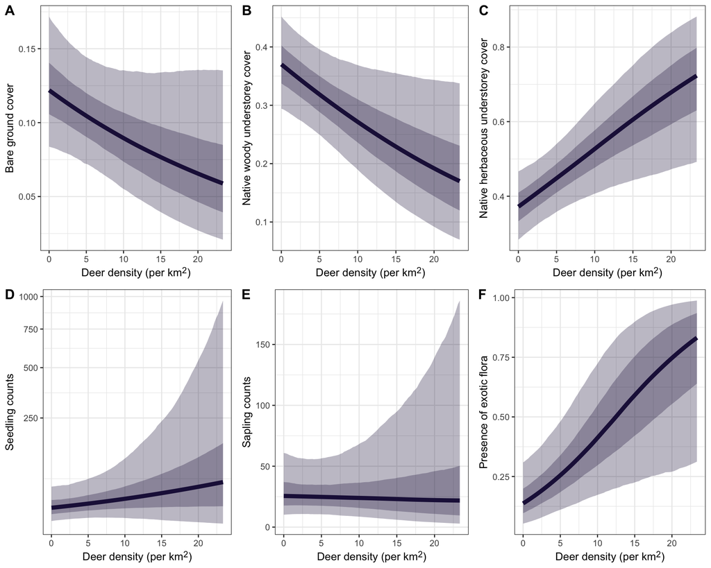

Figure 17: Impact of deer density on a range of vegetation measure, including (A) bare ground cover, (B) native woody understorey, (C) native herbaceous understorey cover, (D) seedlings, (E) saplings, and (F) th presence of exotic species. The line shows the mean estimate, with the shading representing 50% and 90% confidence intervals. Inner and outer shading represents 50% and 90% confidence levels respectively.

```r
plot_list <- conditional_effects(vegfit, effects = "AllDeerDensity", prob = 0.9)
plot_list_50 <- conditional_effects(vegfit, effects = "AllDeerDensity", prob = 0.5)

plot_deer_relationship <- function(plot_data, plot_data_50, yaxis) {
  ggplot(plot_data) +
    geom_ribbon(aes(x = AllDeerDensity, ymin = `lower__`, ymax = `upper__`),
                fill = delwp_cols[["Navy"]], alpha = 0.3) +
    geom_ribbon(aes(x = AllDeerDensity, ymin = `lower__`, ymax = `upper__`),
                fill = delwp_cols[["Navy"]], alpha = 0.3, data = plot_data_50) +
    geom_smooth(aes(x = AllDeerDensity, y = `estimate__`),
                colour = delwp_cols[["Navy"]], method = "loess", formula = y~x, linewidth = 2) +
    ylab(paste(yaxis)) +
    xlab("Deer density (per km^2^)") +
    delwp_theme() +
    theme(axis.title.x = ggtext::element_markdown())

}

vegplot <- cowplot::plot_grid(plot_deer_relationship(plot_list[[1]], plot_list_50[[1]], "Bare ground cover"),
                   plot_deer_relationship(plot_list[[2]], plot_list_50[[2]], "Native woody understorey cover"),
                   plot_deer_relationship(plot_list[[3]], plot_list_50[[3]], "Native herbaceous understorey cover"),
                   plot_deer_relationship(plot_list[[4]], plot_list_50[[4]], "Seedling counts") + scale_y_sqrt(),
                   plot_deer_relationship(plot_list[[5]], plot_list_50[[5]], "Sapling counts"),
                   plot_deer_relationship(plot_list[[6]], plot_list_50[[6]], "Presence of exotic flora"),
                   ncol = 3, labels = "AUTO")

ggsave(plot = vegplot, filename = "outputs/plots/vegetation_effects_plot.png", width = 3400, height = 2200, units = "px")

vegplot
```

We found deer density to have several plausible relationships with several structural vegetation componentsw, including negative relationships with bare ground cover ($\beta$ = -0.035 [90% CI: -0.083, 0.009]), native woody understorey cover ($\beta$ = -0.046 [90% CI: -0.089, -0.003]), and a positive relationship with native non-woody/herbaceous understorey cover ($\beta$ = 0.064 [90% CI: 0.017, 0.111]). We also found strong evidence suggesting the presence of weeds is more likely at sites with higher densities of deer ($\beta$ = 0.149 [90% CI: 0.035, 0.276], $OR$ = 1.161 [90% CI: 1.036, 1.318]). We did not find tangible relationships between deer abundance and seedling or sapling counts.

# Analysis Summary

Our studies detected deer at 148/317 cameras across Victoria and some form of deer sign (camera or transect) at 186/317 sites. Our average estimates of deer density at the 317 sites ranged from 0 to 35.1 deer per km<sup>2</sup>. Across approximately 74,570 km2 of public land in Victoria we estimate total deer abundance of the four species investigated in this study (Sambar, Fallow, Red and Hog) at 224,161 (90 % CI: 173,993 - 294,539. We also find plausible links between deer abundance and increased presence of exotic weed species.

# Comparisons to other studies

Below we show a table of studies that have previously estimated deer density in Australia.

```r
abundance_studies <- readr::read_csv("data/Australian_Deer_Studies_Density_Estimates.csv") %>%
  mutate(`Density LB` = as.numeric(stringr::str_trim(`Density Min`)),
            `Density UB` = as.numeric(stringr::str_trim(`Density Max`)))

abundance_table_present <- abundance_studies %>%
  transmute(State, Species, Title, Author, `Study Sites`, `Year Start`,
            `Year End`, `Density Mean`, `Density LB`,
            `Density UB`) %>%
  arrange(State, Species, Title, `Study Sites`)

write.csv(abundance_table_present, "outputs/tables/other_studies.csv", row.names = FALSE)

abundance_table_present %>%
  kbl("html", digits = 3, caption = "Other studies estimating deer density in Australia") %>%
  kable_styling("striped", font_size = 8) %>%
  collapse_rows(1:3) %>%
  scroll_box(height = "800px", width = "800px")
```

Table 8: Other studies estimating deer density in Australia

| State | Species | Title | Author | Study Sites | Year Start | Year End | Density Mean | Density LB | Density UB |
| --- | --- | --- | --- | --- | --- | --- | --- | --- | --- |
| NSW | Fallow | Estimating deer density and abundance using spatial mark–resight models with camera trap data | Bengsen, A. J., Forsyth, D. M., Ramsey, D. S. L., Amos, M., Brennan, M., Pople, A. R., Comte, S., & Crittle, T | Montane Woodland/Fores in Kosciuszko NP | 2017 | 2019 | 0.29 | 0.12 | 0.53 |
|  | Sambar |  | Bengsen, A. J., Forsyth, D. M., Ramsey, D. S. L., Amos, M., Brennan, M., Pople, A. R., Comte, S., & Crittle, T | Montane Forest in Kosciuszko NP | 2017 | 2019 | 0.73 | 0.33 | 1.35 |
|  |  |  | Bengsen, A. J., Forsyth, D. M., Ramsey, D. S. L., Amos, M., Brennan, M., Pople, A. R., Comte, S., & Crittle, T | Montane Woodland/Fores in Kosciuszko NP | 2017 | 2019 | 2.49 | 1.67 | 3.50 |
|  |  |  | Bengsen, A. J., Forsyth, D. M., Ramsey, D. S. L., Amos, M., Brennan, M., Pople, A. R., Comte, S., & Crittle, T | Wetland Reserve | 2017 | 2019 | 0.48 | 0.24 | 0.84 |
| QLD | Red | I just want to count them! Considerations when choosing a deer population monitoring method | Amos, M., G. Baxter, N. Finch, A. Lisle, and P. Murray | Cressbrook Dam catchment | 2010 | 2012 | 45.75 | 39.80 | 51.70 |
|  |  |  | Amos, M., G. Baxter, N. Finch, A. Lisle, and P. Murray | Cressbrook Dam catchment | 2010 | 2012 | 26.50 | 23.70 | 29.30 |
|  |  |  | Amos, M., G. Baxter, N. Finch, A. Lisle, and P. Murray | Cressbrook Dam catchment | 2011 | 2011 | 26.26 | 12.92 | 53.30 |
|  | Rusa | Estimating deer density and abundance using spatial mark–resight models with camera trap data | Bengsen, A. J., Forsyth, D. M., Ramsey, D. S. L., Amos, M., Brennan, M., Pople, A. R., Comte, S., & Crittle, T | Central Coastal QLD Woodland | 2017 | 2019 | 10.34 | 7.84 | 13.32 |
|  |  |  | Bengsen, A. J., Forsyth, D. M., Ramsey, D. S. L., Amos, M., Brennan, M., Pople, A. R., Comte, S., & Crittle, T | Central Coastal QLD Woodland | 2017 | 2019 | 0.68 | 0.21 | 1.77 |
|  |  |  | Bengsen, A. J., Forsyth, D. M., Ramsey, D. S. L., Amos, M., Brennan, M., Pople, A. R., Comte, S., & Crittle, T | Samsonvale Resivoir | 2017 | 2019 | 3.11 | 1.76 | 5.07 |
| TAS | Fallow | Report of state-wide census of wild fallow deer in Tasmania project: Part A: Baseline aerial survey of fallow deer population, central and north-eastern Tasmania. | Lethbridge, M. R., Stead, M. G., & Wells, C. | Northern Midlands | 2019 | 2019 | 2.70 | 1.67 | 3.71 |
| VIC |  | Estimating deer density and abundance using spatial mark–resight models with camera trap data | Bengsen, A. J., Forsyth, D. M., Ramsey, D. S. L., Amos, M., Brennan, M., Pople, A. R., Comte, S., & Crittle, T | Cardinia Resivoir Woodland | 2017 | 2019 | 2.09 | 1.46 | 2.92 |
|  | Hog | The influence of evolutionary history and body size on partitioning of habitat resources by mammalian herbivores in south-eastern Australia | Davis, N. E., Gordon, I. R., & Coulson, G | Yanicke | 2003 | 2004 | 3.01 | 1.73 | 4.29 |
|  | Red | Estimating deer density and abundance using spatial mark–resight models with camera trap data | Bengsen, A. J., Forsyth, D. M., Ramsey, D. S. L., Amos, M., Brennan, M., Pople, A. R., Comte, S., & Crittle, T | Sugarloaf Resivoir Woodland | 2017 | 2019 | 24.57 | 19.79 | 30.64 |
|  |  |  | Bengsen, A. J., Forsyth, D. M., Ramsey, D. S. L., Amos, M., Brennan, M., Pople, A. R., Comte, S., & Crittle, T | Yan Yean Woodland | 2017 | 2019 | 19.76 | 17.58 | 22.17 |
|  | Sambar | BBRR Feral Pig Survey Project Delicknora 2023 | Durand M., and Tame, A. | Delicknora | NA | NA | 1.70 | 1.70 | 1.70 |
|  |  | BBRR Feral Pig Survey Project Wulgulmerang 2022 | Durand M., and Tame, A. | Wulgulmerang | 2022 | 2022 | 3.29 | 3.29 | 3.29 |
|  |  | BBRR Feral Pig Survey Project Wulgulmerang 2023 | Durand M., and Tame, A. | Wulgulmerang | NA | NA | 6.40 | 6.40 | 6.40 |
|  |  | Estimating deer density and abundance using spatial mark–resight models with camera trap data | Bengsen, A. J., Forsyth, D. M., Ramsey, D. S. L., Amos, M., Brennan, M., Pople, A. R., Comte, S., & Crittle, T | Cardinia Resivoir Woodland | 2017 | 2019 | 11.94 | 8.44 | 16.48 |
|  |  |  | Bengsen, A. J., Forsyth, D. M., Ramsey, D. S. L., Amos, M., Brennan, M., Pople, A. R., Comte, S., & Crittle, T | Yan Yean Woodland | 2017 | 2019 | 3.93 | 2.53 | 6.29 |
|  |  | The application of catch–effort models to estimate the efficacy of aerial shooting operations on sambar deer | Ramsey David S. L., McMaster Damien, Thomas Elaine | Alpine NP - Bogong | 2020 | 2022 | 0.89 | 0.70 | 1.10 |
|  |  |  | Ramsey David S. L., McMaster Damien, Thomas Elaine | Alpine NP - Eastern Alps | 2020 | 2022 | 1.40 | 1.08 | 1.76 |
|  |  |  | Ramsey David S. L., McMaster Damien, Thomas Elaine | Burrowa-Pine | 2020 | 2022 | 0.40 | 0.27 | 0.56 |
|  |  |  | Ramsey David S. L., McMaster Damien, Thomas Elaine | Coopracambra | 2020 | 2022 | 1.12 | 0.04 | 0.20 |
|  |  |  | Ramsey David S. L., McMaster Damien, Thomas Elaine | Croajingolong NP | 2020 | 2022 | 0.61 | 0.44 | 0.81 |
|  |  |  | Ramsey David S. L., McMaster Damien, Thomas Elaine | Errinundra NP | 2020 | 2022 | 0.80 | 0.58 | 1.05 |
|  |  |  | Ramsey David S. L., McMaster Damien, Thomas Elaine | Mount Mitta Mitta RP | 2020 | 2022 | 0.30 | 0.14 | 0.49 |
|  |  |  | Ramsey David S. L., McMaster Damien, Thomas Elaine | Mt Buffalo NP | 2020 | 2022 | 0.78 | 0.64 | 0.94 |
|  |  |  | Ramsey David S. L., McMaster Damien, Thomas Elaine | Snowy River NP | 2020 | 2022 | 1.08 | 0.86 | 1.28 |
|  |  |  | Ramsey David S. L., McMaster Damien, Thomas Elaine | Wabba WP | 2020 | 2022 | 1.30 | 1.02 | 1.60 |
|  |  | The role of wild deer in the transmission of diseases of livestock | Pacioni, Ramsey et al | Gembrook | 2018 | 2020 | 5.90 | 5.70 | 6.10 |
|  |  |  | Pacioni, Ramsey et al | Kinglake | 2018 | 2020 | 6.80 | 3.70 | 10.90 |
|  |  |  | Pacioni, Ramsey et al | Willow Grove | 2018 | 2020 | 6.20 | 5.90 | 6.50 |

# Presence-absence records

The camera traps used in this study also detected numerous other species. We can obtain a table of the presence-absences of these species using the following code:

```r
# Get view
pa <- tbl(con, dbplyr::in_schema("camtrap", "processed_site_substation_presence_absence")) %>%
  dplyr::filter(ProjectShortName %in% !!project_short_name) %>% # Only retrieve cam records for hog deer 2023
  dplyr::collect() %>%
  dplyr::arrange(SiteID)

# Get pa table
pa_table <- pa %>%
  group_by(Species = common_name) %>%
  summarise(`Sites Detected` = sum(Presence)) %>%
  arrange(desc(`Sites Detected`))

write.csv(pa_table, "outputs/tables/other_species.csv", row.names = F)

pa_table %>%
  kbl("html", digits = 3, caption = "Other species and the number of sites (out of 317) that they were recorded at.") %>%
  kable_styling("striped", font_size = 8, full_width = F) %>%
  scroll_box()
```

Table 9: Other species and the number of sites (out of 317) that they were recorded at.

| Species | Sites Detected |
| --- | --- |
| Black-tailed Wallaby | 214 |
| Eastern Grey Kangaroo | 129 |
| Sambar Deer | 104 |
| Red Fox | 92 |
| Bare-nosed Wombat | 91 |
| Common Brush-tailed Possum | 80 |
| Emu | 46 |
| Superb Lyrebird | 38 |
| Pied Currawong | 36 |
| Laughing Kookaburra | 35 |
| Short-beaked Echidna | 32 |
| Dingo | 30 |
| Domestic Cat (feral) | 30 |
| Fallow Deer | 30 |
| Red-necked Wallaby | 25 |
| Ravens and Crows | 24 |
| Hog Deer | 22 |
| Grey Currawong | 19 |
| Southern Long-nosed Bandicoot | 19 |
| Australian Magpie | 18 |
| Western Grey Kangaroo | 17 |
| Rabbits and Hares | 16 |
| European Rabbit | 15 |
| Long-footed Potoroo | 14 |
| Red Deer | 12 |
| Red Wattlebird | 11 |
| Eastern Ring-tailed Possum | 9 |
| Koala | 9 |
| White-winged Chough | 9 |
| Wonga Pigeon | 9 |
| Grey Shrike-thrush | 8 |
| Lace Monitor | 8 |
| Crimson Rosella | 6 |
| Goat (feral) | 6 |
| Australian Raven | 5 |
| Bassian Thrush | 3 |
| Bush Rat | 3 |
| Common Blackbird | 3 |
| Dingo & Dog (feral) | 3 |
| Horse (feral) | 3 |
| Leadbeater’s Possum | 3 |
| Magpie-lark | 3 |
| Mountain Brush-tailed Possum | 3 |
| Pacific Black Duck | 3 |
| Satin Bowerbird | 3 |
| Australian Wood Duck | 2 |
| Black Rat | 2 |
| Eastern Whipbird | 2 |
| Flame Robin | 2 |
| Pig (feral) | 2 |
| White-browed Scrubwren | 2 |
| White-eared Honeyeater | 2 |
| Yellow-tailed Black-Cockatoo | 2 |
| Antechinus | 1 |
| Australian Owlet-nightjar | 1 |
| Black Swan | 1 |
| Black-faced Cuckoo-shrike | 1 |
| Brush Bronzewing | 1 |
| Brushtail Possums | 1 |
| Cattle (feral) | 1 |
| Chestnut Teal | 1 |
| Eastern Rosella | 1 |
| Eastern Yellow Robin | 1 |
| Galah | 1 |
| Grey Butcherbird | 1 |
| Grey Fantail | 1 |
| Morepork | 1 |
| Red Kangaroo | 1 |
| Rufous Fantail | 1 |
| Stubble Quail | 1 |
| Sulphur-crested Cockatoo | 1 |
| White-faced Heron | 1 |

Bürkner, Paul-Christian. 2017. “brms: An R Package for Bayesian Multilevel Models Using Stan.” *Journal of Statistical Software* 80 (1): 1–28. https://doi.org/10.18637/jss.v080.i01.

———. 2018. “Advanced Bayesian Multilevel Modeling with the R Package brms.” *The R Journal* 10 (1): 395–411. https://doi.org/10.32614/RJ-2018-017.

———. 2021. “Bayesian Item Response Modeling in R with brms and Stan.” *Journal of Statistical Software* 100 (5): 1–54. https://doi.org/10.18637/jss.v100.i05.

Forsyth, D M, K Stamation, and L Woodford. 2015. “Distributions of Sambar Deer, Rusa Deer and Sika Deer in Victoria. Unpublished Client Report for the Biosecurity Branch, Department of Economic Development, Jobs, Transport and Resource.” Arthur Rylah Institute for Environmental Research.

———. 2016. “Distributions of Fallow Deer, Red Deer, Hog Deer and Chital Deer in Victoria. Unpublished Client Report for the Biosecurity Branch, Department of Economic Development, Jobs, Transport and Resource.” Arthur Rylah Institute for Environmental Research.

Gabry, Jonah, and Rok Češnovar. 2022. *Cmdstanr: R Interface to ’CmdStan’*.

Miller, David L., Eric Rexstad, Len Thomas, Laura Marshall, and Jeffrey L. Laake. 2019. “Distance Sampling in R.” *Journal of Statistical Software* 89 (1): 1–28. https://doi.org/10.18637/jss.v089.i01.

Vehtari, Aki, Jonah Gabry, Mans Magnusson, Yuling Yao, Paul-Christian Bürkner, Topi Paananen, and Andrew Gelman. 2020. “Loo: Efficient Leave-One-Out Cross-Validation and WAIC for Bayesian Models.” https://mc-stan.org/loo/.

Vehtari, Aki, Andrew Gelman, and Jonah Gabry. 2017. “Practical Bayesian Model Evaluation Using Leave-One-Out Cross-Validation and WAIC.” *Statistics and Computing* 27 (5): 1413–32.